# AnaliseVinhos

**Dessa forma, iremos realizar alguns boxplots combinando propriedades para tentar identificar correlações perdidas:**

Para os gráficos a seguir, devemos considerar para a propriedade qualidade, quanto mais alta, melhor a qualidade do vinho.

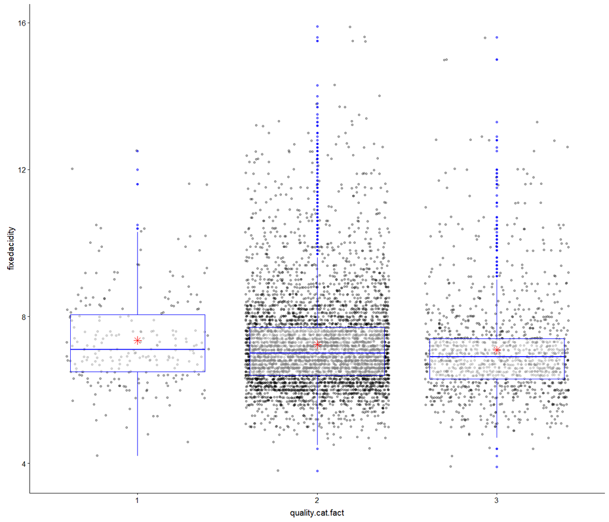

Como podemos ver, a Acidez Fixa não tem quase nenhum efeito na Qualidade. Os valores médios e medianos da acidez fixa permanecem quase inalterados com o aumento da qualidade.

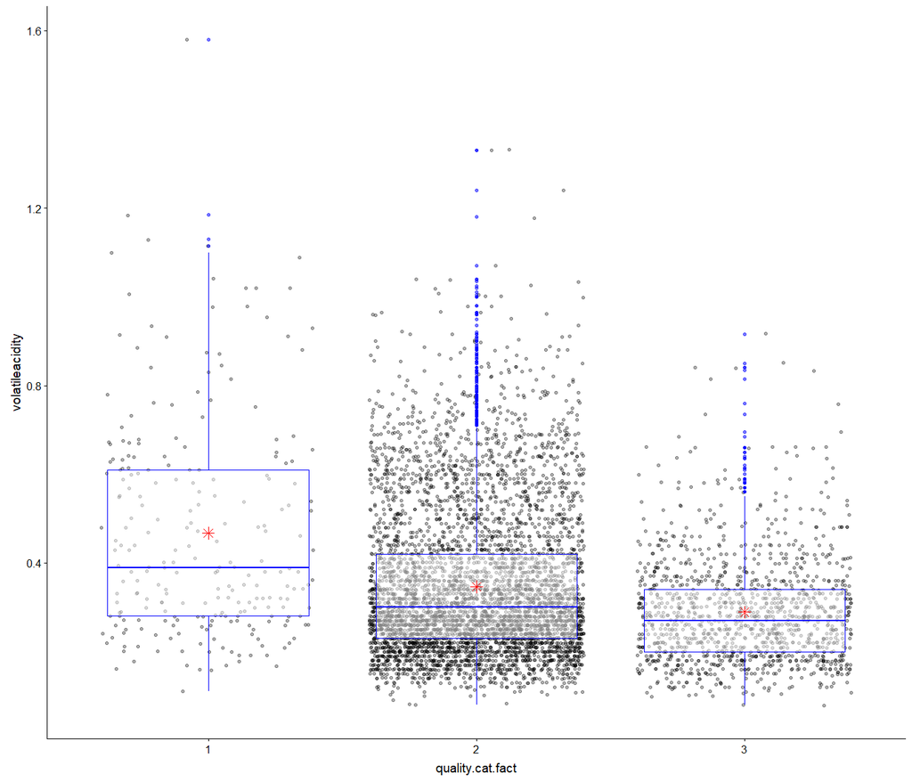

O ácido volátil parece ter um impacto negativo na qualidade do vinho. À medida que o nível de ácido volátil aumenta, a qualidade do vinho degrada.

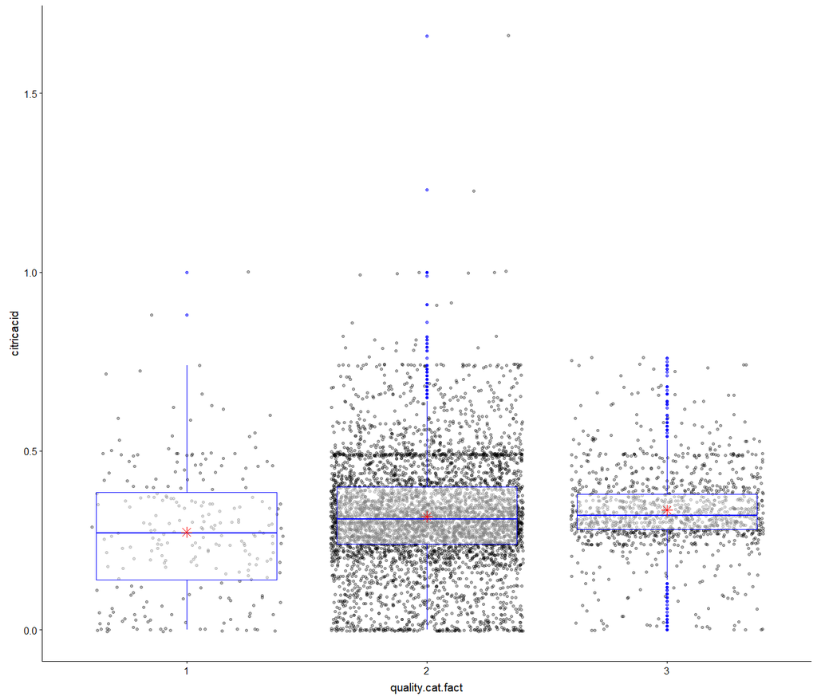

O ácido cítrico parece ter uma correlação positiva com a qualidade do vinho. Melhores vinhos têm maior ácido cítrico.

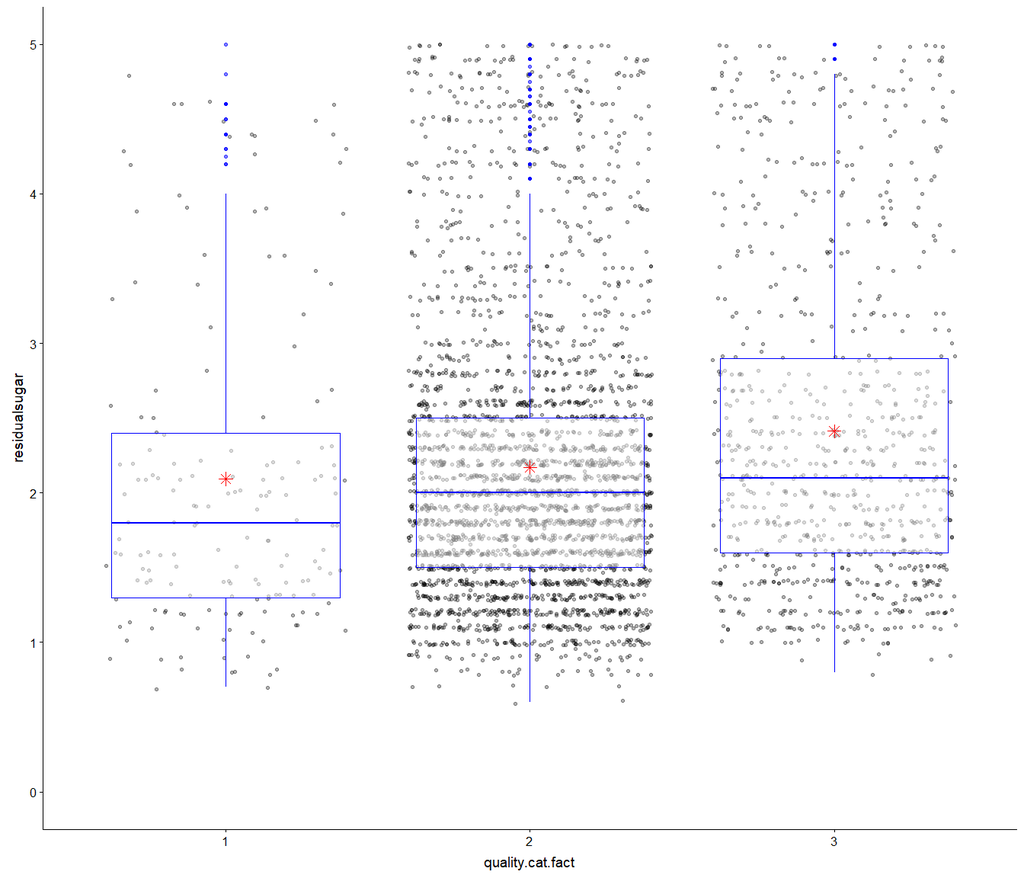

O gráfico acima nos mostra que o Açúcar Residual quase não tem efeito sobre a Qualidade do Vinho. Os valores médios do açúcar residual são quase os mesmos para todas as qualidades de vinho.

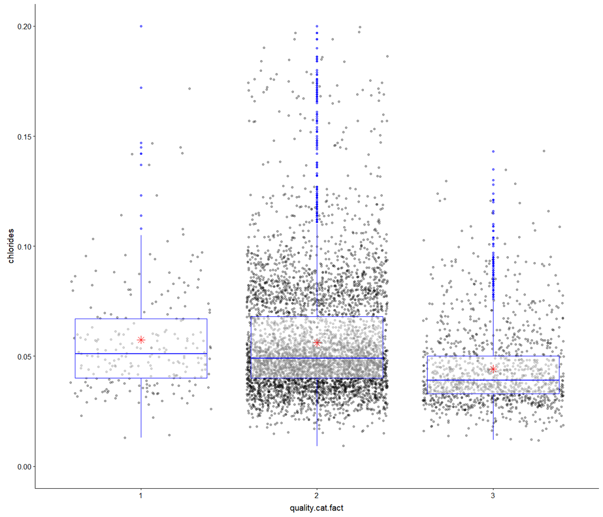

Embora fracamente correlacionado, a partir da diminuição dos valores médios dos cloretos com o aumento da qualidade, aparentemente uma porcentagem menor de Cloreto parece produzir melhores vinhos.

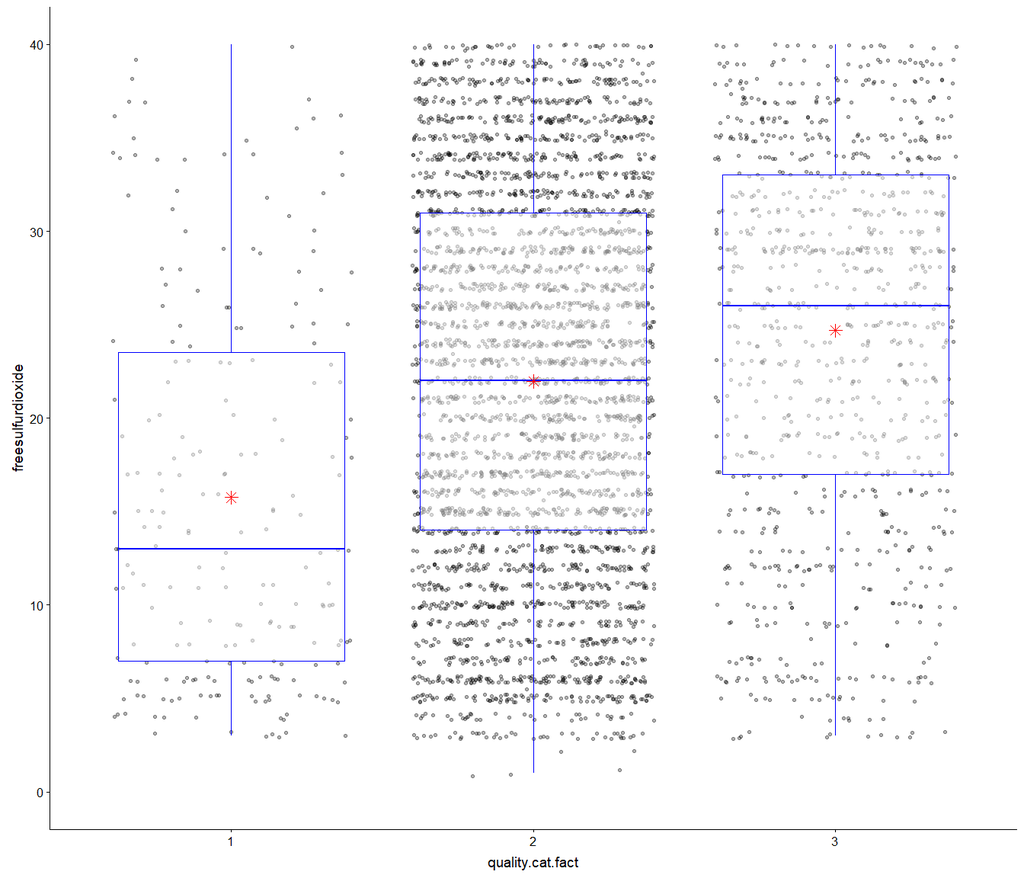

Acima, vemos que uma concentração muito baixa de dióxido de enxofre livre produz vinho pobre e uma concentração muito alta resulta em vinho médio.

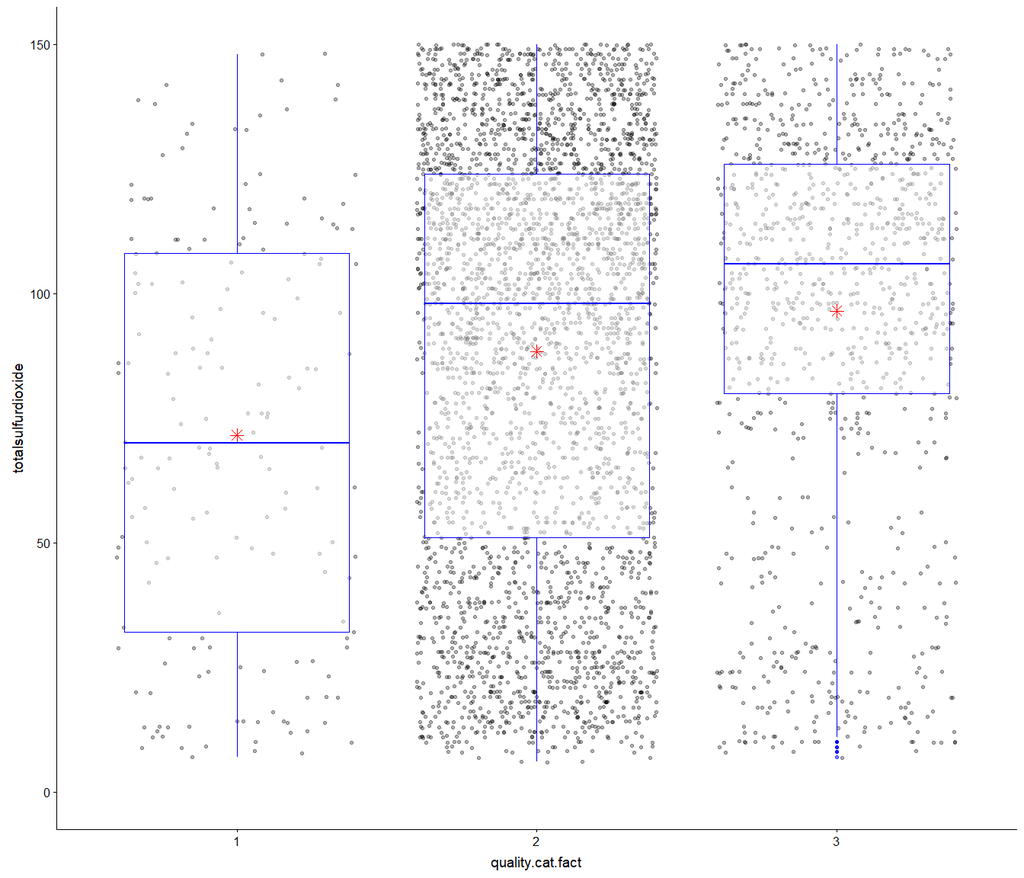

Como este é um subconjunto de dióxido de enxofre livre, vemos um padrão semelhante aqui.

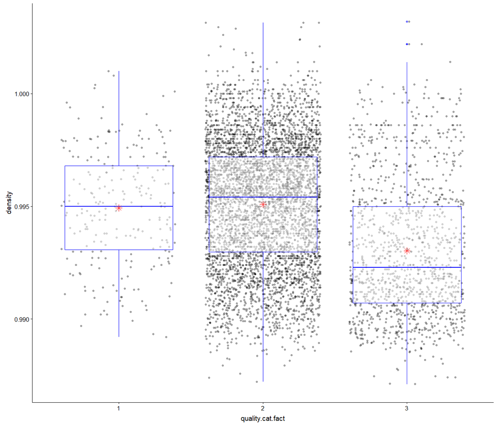

Melhores vinhos parecem ter densidades mais baixas. No entanto, não iremos tirar nenhuma conclusão ainda sobre este ponto porque pode haver uma possibilidade de que a baixa densidade seja devida ao maior teor de álcool, que na verdade é o fator determinante para melhores vinhos.

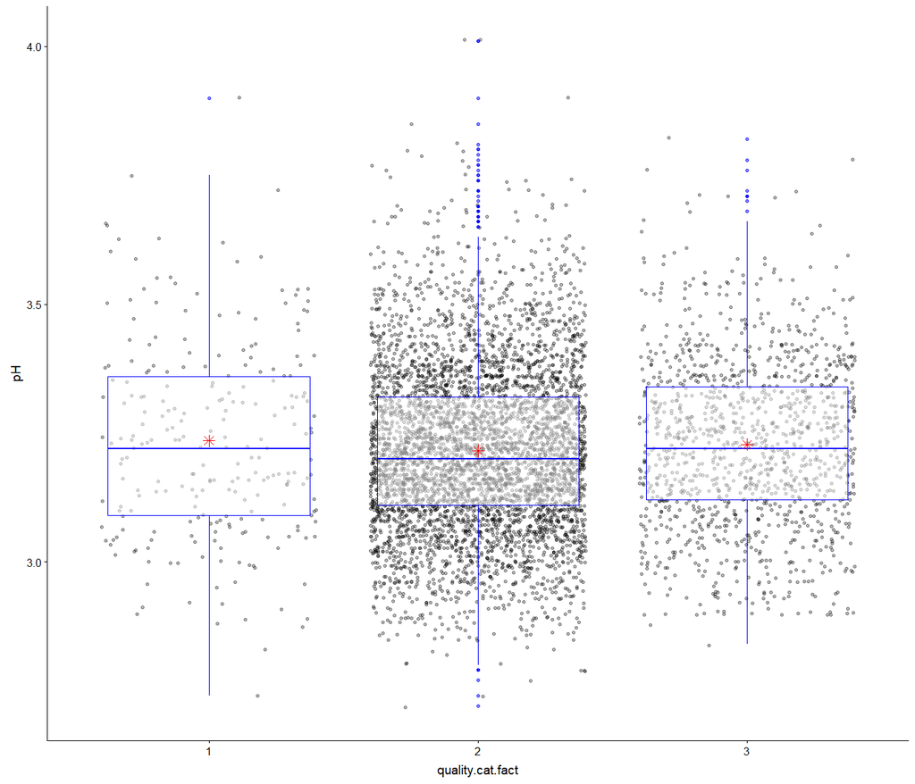

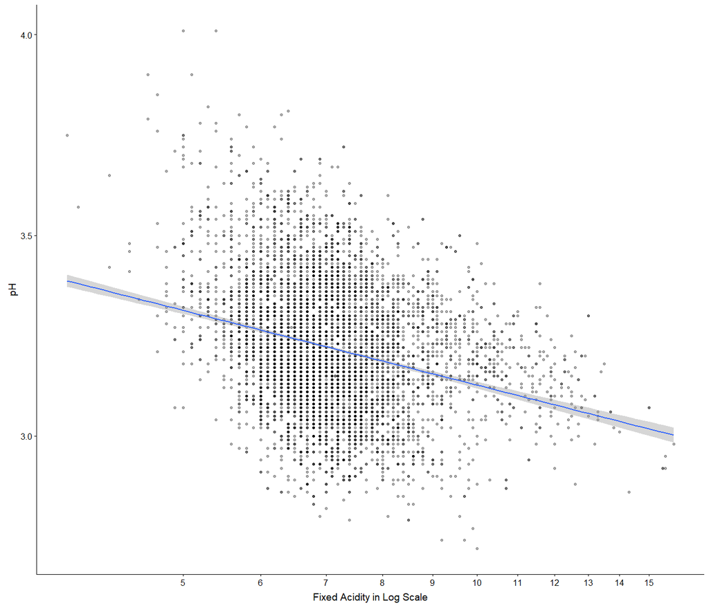

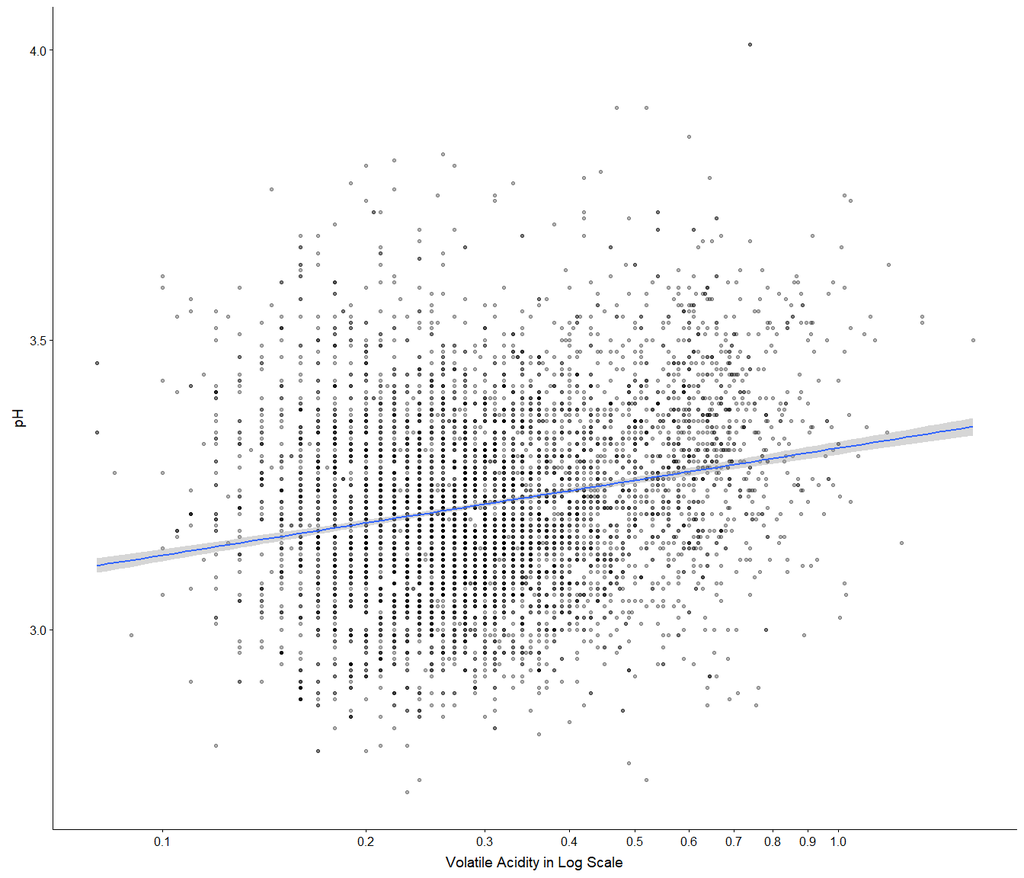

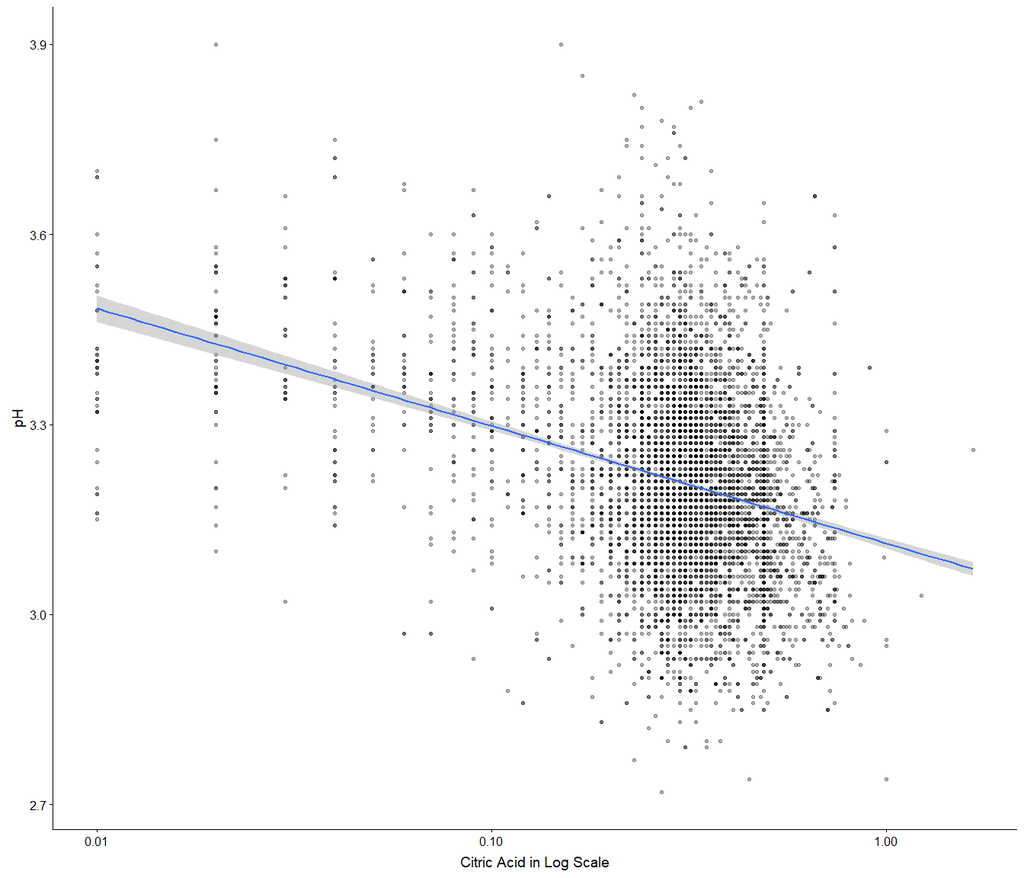

# 2 REGREÇÃO LINEAR

```
##
## Call:
## lm(formula = density ~ totalsulfurdioxide + citricacid + chlorides,
##     data = vinhos.fact)
##
## Residuals:
##        Min         1Q     Median         3Q        Max
## -0.0165166 -0.0020608  0.0001546  0.0020092  0.0091105
##
## Coefficients:
##                     Estimate Std. Error  t value Pr(>|t|)
## (Intercept)        9.916e-01  1.203e-04 8246.309  < 2e-16 ***
## totalsulfurdioxide 6.994e-06  6.319e-07   11.068  < 2e-16 ***
## citricacid         1.057e-03  2.357e-04    4.485 7.43e-06 ***
## chlorides          3.363e-02  1.003e-03   33.532  < 2e-16 ***
## ---
## Signif. codes:  0 '***' 0.001 '**' 0.01 '*' 0.05 '.' 0.1 ' ' 1
##
## Residual standard error: 0.002689 on 6476 degrees of freedom
## Multiple R-squared:  0.1556, Adjusted R-squared:  0.1552
## F-statistic: 397.9 on 3 and 6476 DF,  p-value: < 2.2e-16
```

Portanto, os parâmetros do modelo são estatisticamente significativos. Isso indica a robustez do modelo.

#### 2.0.0.1 Validando o modelo

As principais suposições para validar um modelo linear são as seguintes:

- As variáveis devem ser independentes umas das outras.
- As variáveis individuais devem ser distribuídas normalmente.
- Os resíduos não devem mostrar padrões específicos.

Como todas essas suposições são preenchidas pelas variáveis selecionadas no modelo, a validade do modelo é confirmada.

O gráfico a seguir mostra as densidades previstas usando o modelo de regressão derivado na seção acima.

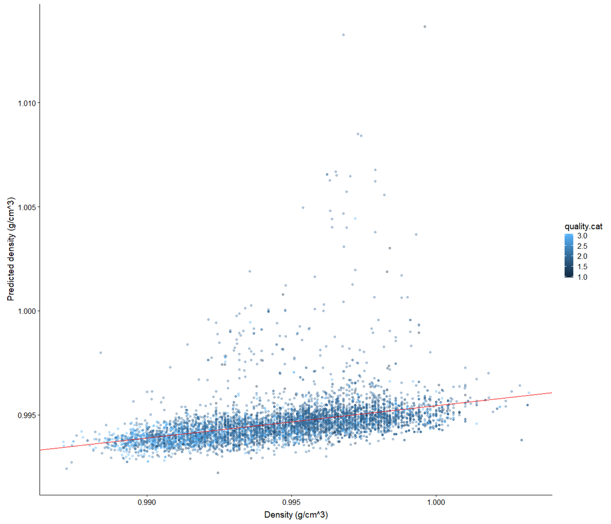

```r
## Gerando modelo de regressão linear simples
fit2 = lm(predict_density ~ density, data = vinhos.fact)

## Plot o modelo
ggplot(aes(density , predict_density), data = vinhos.fact) +
            geom_point(aes(color= quality.cat), alpha = 1/3, position = position_jitter(h = 0)) +
            geom_abline(intercept = coef(fit2)[1], slope = coef(fit2)[2], col = 'red') +
            xlab("Density (g/cm^3)") +
            ylab("Predicted density (g/cm^3)")
```

No gráfico acima vemos o modelo de regressão linear múltipla demonstrado na linha vermelha. Já os pontos azuis são as densidades medidas e as densidades calculadas para os vinhos.

Uma das dificuldades deste conjunto de dados que enfrentamos é que diversas variáveis do dataset estão relacionadas a propriedades técnicas dos vinhos. Para tentar melhor entender essas propriedades técnicas, tentamos buscar mais informações na internet dobre elas. Por exemplo, os valores de densidade de o vinho não podem exceder 1,00 g/cm^3, dessa forma, estabelecemos nosso limite de outlier como 1.005. No entanto, diversas outras propriedades técnicas certamente nos passaram desapercebidas nessa análise.

# 3 REGRESSÃO LOGISTICA

*Definição da variável resposta*

A variavel quality foi escolhida como target ou alvo conforme solicitado, para usar na regressão logistica tivemos que tranformar esta variavel em uma categorica, em nosso caso binaria sendo 1 ou 0. De tal forma que 1 são vinhos bons onde o quality é igual ou superior a 6 e 0 os demais vinhos sendo eles classificados como ruins tais quais inferiores a 6.

```r
dados$quality <- ifelse(dados$quality>=6, yes = 1,no = 0)
```

Transformando vinho em numeros

```r
dados$Vinho<- as.numeric( dados$Vinho)
```

Removendo a coluna vinho porque nossa analise consiste nas caracteristicas quimicas dos vinhos por isso não faz sentido para nossa analise deixar este indexador

```r
dados %>% dplyr::select(.,-c('id_vinho')) -> dados
```

## 3.1 Vinhos Brancos

```r
dados <- dados[dados$Vinho==2,]
```

```r
dados$quality<-factor(dados$quality)
```

```r
head(dados,3)
```

|  | fixedacidity | volatileacidity | citricacid | residualsugar | chlorides | freesulfurdioxide | totalsulfurdioxide | density | pH | sulphates | alcohol | quality | Vinho | quality.cat | totalacidity |
| --- | --- | --- | --- | --- | --- | --- | --- | --- | --- | --- | --- | --- | --- | --- | --- |
| 1 | 6.6 | 0.24 | 0.35 | 7.7 | 0.031 | 36 | 135 | 0.99380 | 3.19 | 0.37 | 10.5 | 0 | 2 | medium | 7.19 |
| 2 | 6.7 | 0.34 | 0.43 | 1.6 | 0.041 | 29 | 114 | 0.99014 | 3.23 | 0.44 | 12.6 | 1 | 2 | medium | 7.47 |
| 4 | 5.4 | 0.18 | 0.24 | 4.8 | 0.041 | 30 | 113 | 0.99445 | 3.42 | 0.40 | 9.4 | 1 | 2 | medium | 5.82 |

### 3.1.1 Separando os dados de treino

```r
#trainIndex <- createDataPartition(dados$Vinho, p=0.70, list=FALSE)
prt <- 2/3
set.seed(999)
trainIndex <- sample(1:NROW(dados), as.integer(prt*NROW(dados)))
```

```r
set.seed(123)
dfTreino <- dados[ trainIndex,]
dfTeste <- dados[-trainIndex,]
```

### 3.1.2 Análise Exploratória dos dados

A análise exploratória está contida no MarkDown onde é possível ver todas as etapas da análise exploratória e todos os recursos utilizados para melhor compreensão dos dados.

### 3.1.3 Treinamento dos modelos e Validação

### 3.1.4 Regressão logistica Vinhos Brancos

A seguir iremos fazer o treinamento do modelo de regressão logistica. Para validarmos os modelos e garantir que o modelo tenha um desempenho aceitavel iremos treina-los com todas as variaveis e em seguida utilizarei o StepWise para selecionar as melhores variaveis.

Apos estas etapas validaremos os resultados da acurracia do modelo, a matriz de confusão e geraremos uma curva ROC para ver o desempenho.

Definição da formula a ser usada no preditor, conforme mencionado acima o alvo ou target será a variavel “quality”.

As variaveis preditoras serão as demais.

```r
y= quality~fixedacidity+volatileacidity+citricacid+residualsugar+chlorides+freesulfurdioxide+totalsulfurdioxide+density+pH+sulphates+alcohol+Vinho
```

### 3.1.5 Treinando o modelo com todas as variaveis

Usando GLM Treinaremos o modelo com a funcionalidade de regressão logistica, para alvos ou target binomiais ou seja variaveis categoricas binarias que possuam dois estados como valores binarios.

```r
modeloComTodasVariaveis <- glm(y, data = dfTreino, family=binomial(link="logit"))
```

### 3.1.6 Exibindo as variaveis do modelo completo

Para treinar e validar o modelo exibiremos aqui as variaveis utilizadas no treino. Em seguida iremos treinar o modelo com as variaveis selecionadas automaticamente para ver se melhoramos o desempenho.

```r
coef(modeloComTodasVariaveis)
```

```
##        (Intercept)       fixedacidity    volatileacidity
##       3.672224e+02       1.568195e-01      -6.585729e+00
##         citricacid      residualsugar          chlorides
##      -3.125668e-02       2.023113e-01       1.493843e+00
##  freesulfurdioxide totalsulfurdioxide            density
##       9.882487e-03      -1.200998e-03      -3.812539e+02
##                 pH          sulphates            alcohol
##       1.553199e+00       1.376492e+00       5.947408e-01
##              Vinho
##                 NA
```

Acima nota-se que temos 12 variaveis apontar isso é importante para exibir a funcionalidde onde o metodo escolhe as variaveis com mais significancia, e melhora o desempenho do nosso modelo.

```r
summary(modeloComTodasVariaveis)
```

```
##
## Call:
## glm(formula = y, family = binomial(link = "logit"), data = dfTreino)
##
## Deviance Residuals:
##     Min       1Q   Median       3Q      Max
## -3.1254  -0.8798   0.4469   0.7989   2.4853
##
## Coefficients: (1 not defined because of singularities)
##                      Estimate Std. Error z value Pr(>|z|)
## (Intercept)         3.672e+02  8.808e+01   4.169 3.06e-05 ***
## fixedacidity        1.568e-01  8.868e-02   1.768 0.077004 .
## volatileacidity    -6.586e+00  5.175e-01 -12.727  < 2e-16 ***
## citricacid         -3.126e-02  3.686e-01  -0.085 0.932422
## residualsugar       2.023e-01  3.344e-02   6.050 1.45e-09 ***
## chlorides           1.494e+00  2.059e+00   0.726 0.468133
## freesulfurdioxide   9.882e-03  3.374e-03   2.929 0.003398 **
## totalsulfurdioxide -1.201e-03  1.491e-03  -0.805 0.420618
## density            -3.813e+02  8.930e+01  -4.269 1.96e-05 ***
## pH                  1.553e+00  4.496e-01   3.455 0.000551 ***
## sulphates           1.376e+00  4.501e-01   3.058 0.002227 **
## alcohol             5.947e-01  1.147e-01   5.186 2.15e-07 ***
## Vinho                      NA         NA      NA       NA
## ---
## Signif. codes:  0 '***' 0.001 '**' 0.01 '*' 0.05 '.' 0.1 ' ' 1
##
## (Dispersion parameter for binomial family taken to be 1)
##
##     Null deviance: 4164.2  on 3264  degrees of freedom
## Residual deviance: 3286.0  on 3253  degrees of freedom
## AIC: 3310
##
## Number of Fisher Scoring iterations: 5
```

### 3.1.7 Usando Stepwise para Selecionar as melhores variaveis

Aqui passamos o modelo como argumento para o metodo o qual nos retorna as variaveis mais importantes.

```r
modeloComStepWise <- modeloComTodasVariaveis %>% stepAIC( trace = FALSE)
```

### 3.1.8 Exibindo as variaveis após utilizar o Stepwise

As variaveis mais significantes para o modelo são exibidas abaixo,

```r
coef(modeloComStepWise)
```

```
##       (Intercept)      fixedacidity   volatileacidity     residualsugar
##      3.728352e+02      1.503128e-01     -6.640521e+00      2.018410e-01
## freesulfurdioxide           density                pH         sulphates
##      8.333739e-03     -3.866813e+02      1.521005e+00      1.319316e+00
##           alcohol
##      5.871920e-01
```

Após a utilização do metodo notasse que o Stepwise selecionou 8 variaveis variaveis estas que são as mais significativas para o modelo.

```r
summary(modeloComStepWise)
```

```
##
## Call:
## glm(formula = quality ~ fixedacidity + volatileacidity + residualsugar +
##     freesulfurdioxide + density + pH + sulphates + alcohol, family = binomial(link = "logit"),
##     data = dfTreino)
##
## Deviance Residuals:
##     Min       1Q   Median       3Q      Max
## -3.0690  -0.8806   0.4456   0.8001   2.4751
##
## Coefficients:
##                     Estimate Std. Error z value Pr(>|z|)
## (Intercept)        3.728e+02  8.402e+01   4.437 9.11e-06 ***
## fixedacidity       1.503e-01  8.610e-02   1.746 0.080839 .
## volatileacidity   -6.641e+00  5.016e-01 -13.237  < 2e-16 ***
## residualsugar      2.018e-01  3.201e-02   6.306 2.87e-10 ***
## freesulfurdioxide  8.334e-03  2.703e-03   3.083 0.002046 **
## density           -3.867e+02  8.511e+01  -4.543 5.54e-06 ***
## pH                 1.521e+00  4.381e-01   3.472 0.000517 ***
## sulphates          1.319e+00  4.454e-01   2.962 0.003055 **
## alcohol            5.872e-01  1.139e-01   5.154 2.55e-07 ***
## ---
## Signif. codes:  0 '***' 0.001 '**' 0.01 '*' 0.05 '.' 0.1 ' ' 1
##
## (Dispersion parameter for binomial family taken to be 1)
##
##     Null deviance: 4164.2  on 3264  degrees of freedom
## Residual deviance: 3287.2  on 3256  degrees of freedom
## AIC: 3305.2
##
## Number of Fisher Scoring iterations: 5
```

### 3.1.9 Fazendo a predição dos dados de testes usando o modelo com todas as variaveis

```r
resultadoPredicaoTestes <- modeloComTodasVariaveis %>% predict(dfTeste, type = "response")
predicaoResultado <- ifelse(resultadoPredicaoTestes > 0.5, 1, 0)
```

### 3.1.10 Calculando a precisão (accuracy) do modelo com todas as variaveis

Abaixo o modelo exibe o calculo da precisão do modelo. Creio que para as particularidades da base de dados o resultado é otimo.

```r
mean(predicaoResultado == dfTeste$quality)
```

```
## [1] 0.7421923
```

```r
resultadoPredicaoTestesStepwise <- predict(modeloComStepWise, dfTeste, type = "response",na.action = na.pass)
predicaoResultadoStepWise <- ifelse(resultadoPredicaoTestesStepwise > 0.5, 1, 0)
```

### 3.1.11 Calculando a precisão (accuracy) do modelo com as variaveis escolhidas pelo modelo

```r
mean(predicaoResultadoStepWise == dfTeste$quality)
```

```
## [1] 0.7477036
```

Com a seleção de variaveis alem de diminuirmos a quantidade de variaveis, tambem obtivemos uma melhoria no modelo onde o mesmo beira cerca de 75% se arredondarmos, o que é otimo, mas para comprovar que o modelo é eficiente seguiremos buscando mais dados para comprovar

### 3.1.12 Matriz de confusão com todos os dados

```r
confusionMatrix(data = as.factor(as.numeric(resultadoPredicaoTestes > 0.5)), reference = dfTeste$quality)
```

```
## Confusion Matrix and Statistics
##
##           Reference
## Prediction   0   1
##          0 283 158
##          1 263 929
##
##                Accuracy : 0.7422
##                  95% CI : (0.7202, 0.7633)
##     No Information Rate : 0.6656
##     P-Value [Acc > NIR] : 1.251e-11
##
##                   Kappa : 0.3917
##
##  Mcnemar's Test P-Value : 4.006e-07
##
##             Sensitivity : 0.5183
##             Specificity : 0.8546
##          Pos Pred Value : 0.6417
##          Neg Pred Value : 0.7794
##              Prevalence : 0.3344
##          Detection Rate : 0.1733
##    Detection Prevalence : 0.2701
##       Balanced Accuracy : 0.6865
##
##        'Positive' Class : 0
##
```

### 3.1.13 Matriz de confusão com StepWise

```r
confusionMatrix(data = as.factor(as.numeric(predicaoResultadoStepWise > 0.5)), reference = dfTeste$quality)
```

```
## Confusion Matrix and Statistics
##
##           Reference
## Prediction   0   1
##          0 285 151
##          1 261 936
##
##                Accuracy : 0.7477
##                  95% CI : (0.7259, 0.7686)
##     No Information Rate : 0.6656
##     P-Value [Acc > NIR] : 3.768e-13
##
##                   Kappa : 0.4033
##
##  Mcnemar's Test P-Value : 7.872e-08
##
##             Sensitivity : 0.5220
##             Specificity : 0.8611
##          Pos Pred Value : 0.6537
##          Neg Pred Value : 0.7820
##              Prevalence : 0.3344
##          Detection Rate : 0.1745
##    Detection Prevalence : 0.2670
##       Balanced Accuracy : 0.6915
##
##        'Positive' Class : 0
##
```

```r
probabilidades = cbind(dfTeste,predicaoResultadoStepWise)
```

```r
vlrcalcPredPerformance = prediction(predicaoResultadoStepWise ,probabilidades$quality)
```

### 3.1.14 Calculando a área sob a curva AUC

```r
auc = performance(vlrcalcPredPerformance,"auc")
```

```r
perf = performance(vlrcalcPredPerformance, "tpr", "fpr")
attr(perf, "y.values")[[1]][2]
```

```
## [1] 0.8610856
```

Plotanto o grafico fica mais visivel a performance do modelo em relação a curva roc.

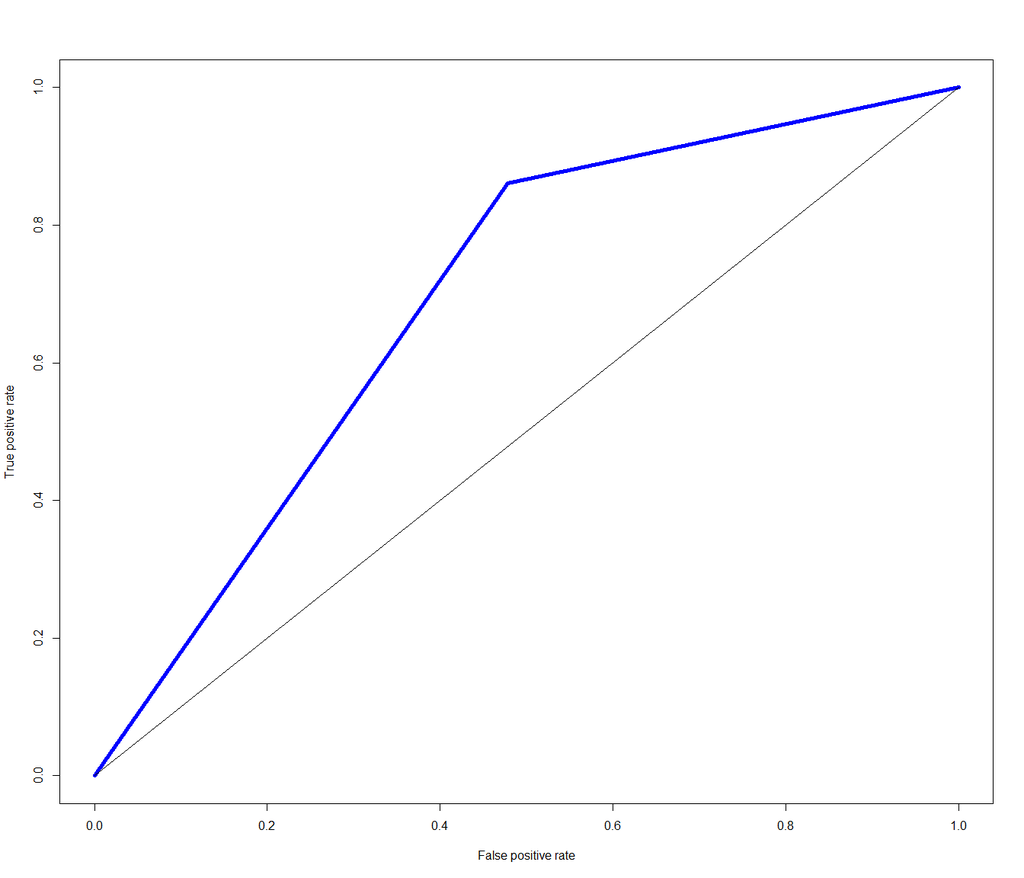

```r
plot(perf, col = "blue", lwd = 5)
lines(x = c(0,1),y=c(0,1))
```

## 3.2 Vinhos Vermelhos

```r
dados = data.table::copy(vinhos)
```

```r
dados$quality <- ifelse(dados$quality>=6, yes = 1,no = 0)
dados$Vinho<- as.numeric( dados$Vinho)
```

```r
dim(dados)
```

```
## [1] 6497   16
```

Removendo a coluna vinho porque nossa analise consiste nas caracteristicas quimicas dos vinhos por isso não faz sentido para nossa analise deixar este indexador

```r
dados %>% dplyr::select(.,-c('id_vinho')) -> dados
```

```r
dados <- dados[dados$Vinho==1,]
dados$quality<-factor(dados$quality)
head(dados,3)
```

|  | fixedacidity | volatileacidity | citricacid | residualsugar | chlorides | freesulfurdioxide | totalsulfurdioxide | density | pH | sulphates | alcohol | quality | Vinho | quality.cat | totalacidity |
| --- | --- | --- | --- | --- | --- | --- | --- | --- | --- | --- | --- | --- | --- | --- | --- |
| 3 | 10.6 | 0.31 | 0.49 | 2.2 | 0.063 | 18 | 40 | 0.99760 | 3.14 | 0.51 | 9.8 | 1 | 1 | medium | 11.40 |
| 6 | 6.8 | 0.50 | 0.11 | 1.5 | 0.075 | 16 | 49 | 0.99545 | 3.36 | 0.79 | 9.5 | 0 | 1 | medium | 7.41 |
| 7 | 6.6 | 0.61 | 0.00 | 1.6 | 0.069 | 4 | 8 | 0.99396 | 3.33 | 0.37 | 10.4 | 0 | 1 | bad | 7.21 |

### 3.2.2 Separando os dados de treino

```r
set.seed(123)
prt <- 2/3
set.seed(10)
trainIndex <- sample(1:NROW(dados), as.integer(prt*NROW(dados)))
dfTreino <- dados[ trainIndex,]
dfTeste <- dados[-trainIndex,]
```

### 3.2.3 Análise Exploratória dos dados

A análise exploratória está contida no MarkDown onde é possível ver todas as etapas da análise exploratória e todos os recursos utilizados para melhor compreensão dos dados.

### 3.2.4 Treinamento dos modelos e Validação

A seguir iremos fazer o treinamento do modelo de regressão logistica. Para validarmos os modelos e garantir que o modelo tenha um desempenho aceitavel iremos treina-los com todas as variaveis e em seguida utilizarei o StepWise para selecionar as melhores variaveis.

Apos estas etapas validaremos os resultados da acurracia do modelo, a matriz de confusão e geraremos uma curva ROC para ver o desempenho.

## 3.3 Definição da formula a ser usada no preditor, conforme mencionado acima o alvo ou target será a variavel “quality”.

As variaveis preditoras serão as demais.

```r
y= quality~fixedacidity+volatileacidity+citricacid+residualsugar+chlorides+freesulfurdioxide+totalsulfurdioxide+density+pH+sulphates+alcohol+Vinho
```

### 3.3.1 Treinando o modelo com todas as variaveis

Usando GLM Treinaremos o modelo com a funcionalidade de regressão logistica, para alvos ou target binomiais ou seja variaveis categoricas binarias que possuam dois estados como valores binarios.

```r
modeloComTodasVariaveis <- glm(y, data = dfTreino, family=binomial(link="logit"))
```

### 3.3.2 Exibindo as variaveis do modelo completo

Para treinar e validar o modelo exibiremos aqui as variaveis utilizadas no treino. Em seguida iremos treinar o modelo com as variaveis selecionadas automaticamente para ver se melhoramos o desempenho.

```r
coef(modeloComTodasVariaveis)
```

```
##        (Intercept)       fixedacidity    volatileacidity
##       268.38783925         0.45971953        -3.23647999
##         citricacid      residualsugar          chlorides
##        -1.10243411         0.15807559        -2.27694980
##  freesulfurdioxide totalsulfurdioxide            density
##         0.01804471        -0.01533756      -283.25907900
##                 pH          sulphates            alcohol
##         1.84240903         2.04241027         0.49354505
##              Vinho
##                 NA
```

Acima nota-se que temos 12 variaveis apontar isso é importante para exibir a funcionalidde onde o metodo escolhe as variaveis com mais significancia, e melhora o desempenho do nosso modelo.

```r
summary(modeloComTodasVariaveis)
```

```
##
## Call:
## glm(formula = y, family = binomial(link = "logit"), data = dfTreino)
##
## Deviance Residuals:
##     Min       1Q   Median       3Q      Max
## -2.2393  -0.8912   0.3516   0.8895   3.1933
##
## Coefficients: (1 not defined because of singularities)
##                      Estimate Std. Error z value Pr(>|z|)
## (Intercept)         2.684e+02  9.395e+01   2.857 0.004282 **
## fixedacidity        4.597e-01  1.184e-01   3.882 0.000104 ***
## volatileacidity    -3.236e+00  5.843e-01  -5.539 3.04e-08 ***
## citricacid         -1.102e+00  6.615e-01  -1.667 0.095591 .
## residualsugar       1.581e-01  6.530e-02   2.421 0.015488 *
## chlorides          -2.277e+00  1.833e+00  -1.242 0.214108
## freesulfurdioxide   1.804e-02  9.675e-03   1.865 0.062164 .
## totalsulfurdioxide -1.534e-02  3.309e-03  -4.635 3.57e-06 ***
## density            -2.833e+02  9.601e+01  -2.950 0.003176 **
## pH                  1.842e+00  8.647e-01   2.131 0.033107 *
## sulphates           2.042e+00  5.275e-01   3.872 0.000108 ***
## alcohol             4.935e-01  1.159e-01   4.259 2.06e-05 ***
## Vinho                      NA         NA      NA       NA
## ---
## Signif. codes:  0 '***' 0.001 '**' 0.01 '*' 0.05 '.' 0.1 ' ' 1
##
## (Dispersion parameter for binomial family taken to be 1)
##
##     Null deviance: 1474.2  on 1065  degrees of freedom
## Residual deviance: 1153.0  on 1054  degrees of freedom
## AIC: 1177
##
## Number of Fisher Scoring iterations: 4
```

### 3.3.3 Usando Stepwise para Selecionar as melhores variaveis

Aqui passamos o modelo como argumento para o metodo o qual nos retorna as variaveis mais importantes.

```r
modeloComStepWise <- modeloComTodasVariaveis %>% MASS::stepAIC( trace = FALSE)
```

### 3.3.4 Exibindo as variaveis após utilizar o Stepwise

As variaveis mais significantes para o modelo são exibidas abaixo,

```r
coef(modeloComStepWise)
```

```
##        (Intercept)       fixedacidity    volatileacidity
##       277.92344827         0.49846864        -3.44141738
##         citricacid      residualsugar  freesulfurdioxide
##        -1.36249165         0.15756811         0.01733705
## totalsulfurdioxide            density                 pH
##        -0.01464631      -294.09177350         2.11254409
##          sulphates            alcohol
##         1.77294001         0.51084620
```

Após a utilização do metodo notasse que o Stepwise selecionou 10 variaveis variaveis estas que são as mais significativas para o modelo.

```r
summary(modeloComStepWise)
```

```
##
## Call:
## glm(formula = quality ~ fixedacidity + volatileacidity + citricacid +
##     residualsugar + freesulfurdioxide + totalsulfurdioxide +
##     density + pH + sulphates + alcohol, family = binomial(link = "logit"),
##     data = dfTreino)
##
## Deviance Residuals:
##     Min       1Q   Median       3Q      Max
## -2.2352  -0.9054   0.3449   0.8921   3.2466
##
## Coefficients:
##                      Estimate Std. Error z value Pr(>|z|)
## (Intercept)         2.779e+02  9.388e+01   2.960 0.003072 **
## fixedacidity        4.985e-01  1.147e-01   4.344 1.40e-05 ***
## volatileacidity    -3.441e+00  5.625e-01  -6.118 9.49e-10 ***
## citricacid         -1.362e+00  6.282e-01  -2.169 0.030086 *
## residualsugar       1.576e-01  6.528e-02   2.414 0.015794 *
## freesulfurdioxide   1.734e-02  9.640e-03   1.798 0.072103 .
## totalsulfurdioxide -1.465e-02  3.252e-03  -4.504 6.68e-06 ***
## density            -2.941e+02  9.587e+01  -3.068 0.002158 **
## pH                  2.113e+00  8.408e-01   2.512 0.011989 *
## sulphates           1.773e+00  4.770e-01   3.717 0.000202 ***
## alcohol             5.108e-01  1.158e-01   4.413 1.02e-05 ***
## ---
## Signif. codes:  0 '***' 0.001 '**' 0.01 '*' 0.05 '.' 0.1 ' ' 1
##
## (Dispersion parameter for binomial family taken to be 1)
##
##     Null deviance: 1474.2  on 1065  degrees of freedom
## Residual deviance: 1154.6  on 1055  degrees of freedom
## AIC: 1176.6
##
## Number of Fisher Scoring iterations: 4
```

### 3.3.5 Fazendo a predição dos dados de testes usando o modelo com todas as variaveis

```r
resultadoPredicaoTestes <- modeloComTodasVariaveis %>% predict(dfTeste, type = "response")
predicaoResultado <- ifelse(resultadoPredicaoTestes > 0.5, 1, 0)
```

### 3.3.6 Calculando a precisão (accuracy) do modelo com todas as variaveis

Abaixo o modelo exibe o calculo da precisão do modelo. Creio que para as particularidades da base de dados o resultado é otimo.

```r
mean(predicaoResultado == dfTeste$quality)
```

```
## [1] 0.7711069
```

```r
resultadoPredicaoTestesStepwise <- predict(modeloComStepWise, dfTeste, type = "response",na.action = na.pass)
predicaoResultadoStepWise <- ifelse(resultadoPredicaoTestesStepwise > 0.5, 1, 0)
```

### 3.3.7 Calculando a precisão (accuracy) do modelo com as variaveis escolhidas pelo modelo

```r
mean(predicaoResultadoStepWise == dfTeste$quality)
```

```
## [1] 0.7711069
```

### 3.3.8 Matriz de confusão com todos os dados

```r
caret::confusionMatrix(data = as.factor(as.numeric(resultadoPredicaoTestes > 0.5)), reference = dfTeste$quality)
```

```
## Confusion Matrix and Statistics
##
##           Reference
## Prediction   0   1
##          0 187  67
##          1  55 224
##
##                Accuracy : 0.7711
##                  95% CI : (0.7331, 0.8061)
##     No Information Rate : 0.546
##     P-Value [Acc > NIR] : <2e-16
##
##                   Kappa : 0.5402
##
##  Mcnemar's Test P-Value : 0.3193
##
##             Sensitivity : 0.7727
##             Specificity : 0.7698
##          Pos Pred Value : 0.7362
##          Neg Pred Value : 0.8029
##              Prevalence : 0.4540
##          Detection Rate : 0.3508
##    Detection Prevalence : 0.4765
##       Balanced Accuracy : 0.7712
##
##        'Positive' Class : 0
##
```

### 3.3.9 Matriz de confusão com StepWise

```r
caret::confusionMatrix(data = as.factor(as.numeric(predicaoResultadoStepWise > 0.5)), reference = dfTeste$quality)
```

```
## Confusion Matrix and Statistics
##
##           Reference
## Prediction   0   1
##          0 185  65
##          1  57 226
##
##                Accuracy : 0.7711
##                  95% CI : (0.7331, 0.8061)
##     No Information Rate : 0.546
##     P-Value [Acc > NIR] : <2e-16
##
##                   Kappa : 0.5396
##
##  Mcnemar's Test P-Value : 0.5262
##
##             Sensitivity : 0.7645
##             Specificity : 0.7766
##          Pos Pred Value : 0.7400
##          Neg Pred Value : 0.7986
##              Prevalence : 0.4540
##          Detection Rate : 0.3471
##    Detection Prevalence : 0.4690
##       Balanced Accuracy : 0.7705
##
##        'Positive' Class : 0
##
```

```r
probabilidades = cbind(dfTeste,predicaoResultadoStepWise)
```

```r
vlrcalcPredPerformance = prediction(predicaoResultadoStepWise ,probabilidades$quality)
```

### 3.3.10 Calculando a área sob a curva AUC

```r
auc = performance(vlrcalcPredPerformance,"auc")
perf = performance(vlrcalcPredPerformance, "tpr", "fpr")
```

```r
attr(perf, "y.values")[[1]][2]
```

```
## [1] 0.7766323
```

Plota curva ROC

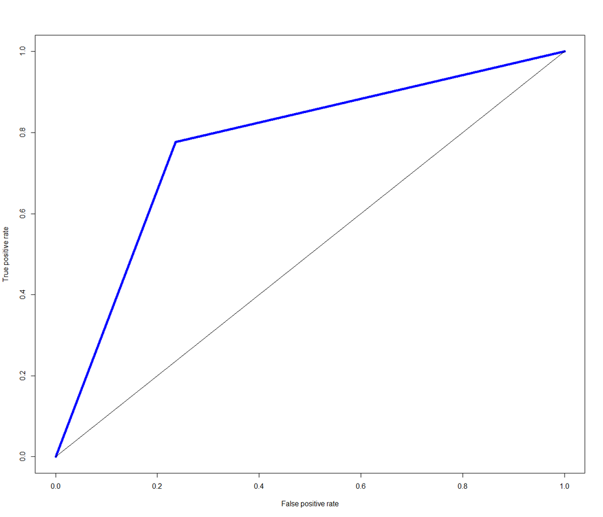

```r
plot(perf, col = "blue", lwd = 5)
lines(x = c(0,1),y=c(0,1))
```

## 3.4 Conclusões sobre a Regressão Logistica

Ao analisar as matrizes de confusão dos vinhos brancos com e sem stepwise e os vinhos vermelhos com e sem stepwize notasse baixa diferença na acurracia da matriz de confução o que torna este preditor qualificado a entrar em produção.

# 4 ANÁLISE DE CLUSTERS

A analise de clusters foi dividida em 2. Em um primeiro momento fazemos toda a analise sem PCA e depois com PCA.

Isso e feito para que possamos cruzar os dados obtidos das duas formas.

## 4.1 Sem PCA

Como ja notamos, os vinhos precisam ser divididos em vermelhos e brancos, para a clusterizacao vamos trabalhar com 3 cenarios: - Todos juntos - Brancos - Vermelhos

```r
wineCust <- vinhos
winecust_red <- vinhosTintos
winecust_white <- vinhosBrancos
```

Para que possamos entender a correlacao, vamos normalizar os datasets:

```r
#wineCust_scale <- scale(select (wineCust,-c(Vinho,id_vinho)))
#scale(wineCust %>% dplyr::select(.,-c('id_vinho','Vinho'))) -> wineCust_scale
scale(vinhos.fact %>% dplyr::select(.,-c('id_vinho','Vinho','quality.cat','quality.cat.fact','predict_density'))) -> wineCust_scale
summary(wineCust_scale)
```

```
##   fixedacidity     volatileacidity     citricacid       residualsugar
##  Min.   :-2.6443   Min.   :-1.5768   Min.   :-2.19273   Min.   :-1.0307
##  1st Qu.:-0.6287   1st Qu.:-0.6651   1st Qu.:-0.47159   1st Qu.:-0.7737
##  Median :-0.1635   Median :-0.3005   Median :-0.05852   Median :-0.5167
##  Mean   : 0.0000   Mean   : 0.0000   Mean   : 0.00000   Mean   : 0.0000
##  3rd Qu.: 0.3791   3rd Qu.: 0.3681   3rd Qu.: 0.49224   3rd Qu.: 0.5755
##  Max.   : 6.7361   Max.   : 7.5396   Max.   : 9.23562   Max.   : 4.4199
##    chlorides       freesulfurdioxide  totalsulfurdioxide
##  Min.   :-1.3461   Min.   :-1.68934   Min.   :-1.9451
##  1st Qu.:-0.5143   1st Qu.:-0.77255   1st Qu.:-0.6864
##  Median :-0.2562   Median :-0.08497   Median : 0.0405
##  Mean   : 0.0000   Mean   : 0.00000   Mean   : 0.0000
##  3rd Qu.: 0.2601   3rd Qu.: 0.60262   3rd Qu.: 0.7142
##  Max.   :15.9203   Max.   : 6.64766   Max.   : 4.4462
##     density               pH             sulphates          alcohol
##  Min.   :-2.58566   Min.   :-3.09904   Min.   :-2.0903   Min.   :-7.8414
##  1st Qu.:-0.80488   1st Qu.:-0.67446   1st Qu.:-0.6791   1st Qu.:-0.8129
##  Median : 0.07013   Median :-0.05277   Median :-0.1415   Median :-0.1548
##  Mean   : 0.00000   Mean   : 0.00000   Mean   : 0.0000   Mean   : 0.0000
##  3rd Qu.: 0.77766   3rd Qu.: 0.63109   3rd Qu.: 0.4632   3rd Qu.: 0.6679
##  Max.   : 2.91392   Max.   : 4.92075   Max.   : 9.8711   Max.   : 3.6296
##     quality         totalacidity
##  Min.   :-3.2317   Min.   :-2.7061
##  1st Qu.:-0.9394   1st Qu.:-0.6144
##  Median : 0.2068   Median :-0.1946
##  Mean   : 0.0000   Mean   : 0.0000
##  3rd Qu.: 0.2068   3rd Qu.: 0.3699
##  Max.   : 3.6452   Max.   : 6.6414
```

```r
#wineCust_red_scale <- scale(select (winecust_red,-c(Vinho,id_vinho)))
#scale(winecust_red %>% dplyr::select(.,-c('id_vinho','Vinho'))) -> wineCust_red_scale
scale(vinhosTintos.fact %>% dplyr::select(.,-c('id_vinho','Vinho','quality.cat','quality.cat.fact'))) -> wineCust_red_scale
summary(wineCust_red_scale)
```

```
##   fixedacidity     volatileacidity      citricacid       residualsugar
##  Min.   :-2.1373   Min.   :-2.27778   Min.   :-1.38793   Min.   :-1.4481
##  1st Qu.:-0.6999   1st Qu.:-0.77193   1st Qu.:-0.92586   1st Qu.:-0.5222
##  Median :-0.2399   Median :-0.04689   Median :-0.05305   Median :-0.2444
##  Mean   : 0.0000   Mean   : 0.00000   Mean   : 0.00000   Mean   : 0.0000
##  3rd Qu.: 0.5075   3rd Qu.: 0.62238   3rd Qu.: 0.76841   3rd Qu.: 0.1260
##  Max.   : 4.3598   Max.   : 5.86498   Max.   : 3.74622   Max.   : 6.0518
##    chlorides       freesulfurdioxide totalsulfurdioxide
##  Min.   :-1.6074   Min.   :-1.4431   Min.   :-1.2283
##  1st Qu.:-0.3684   1st Qu.:-0.8560   1st Qu.:-0.7395
##  Median :-0.1761   Median :-0.1709   Median :-0.2507
##  Mean   : 0.0000   Mean   : 0.0000   Mean   : 0.0000
##  3rd Qu.: 0.0589   3rd Qu.: 0.5142   3rd Qu.: 0.4824
##  Max.   :11.1892   Max.   : 5.1138   Max.   : 7.4170
##     density                pH            sulphates          alcohol
##  Min.   :-3.590733   Min.   :-3.6990   Min.   :-1.9319   Min.   :-8.1171
##  1st Qu.:-0.604687   1st Qu.:-0.6577   1st Qu.:-0.6369   1st Qu.:-0.7783
##  Median : 0.000082   Median :-0.0106   Median :-0.2248   Median :-0.1770
##  Mean   : 0.000000   Mean   : 0.0000   Mean   : 0.0000   Mean   : 0.0000
##  3rd Qu.: 0.583251   3rd Qu.: 0.5718   3rd Qu.: 0.4227   3rd Qu.: 0.5961
##  Max.   : 3.499101   Max.   : 4.5191   Max.   : 7.8989   Max.   : 3.8603
##     quality         totalacidity
##  Min.   :-3.2612   Min.   :-2.1002
##  1st Qu.:-0.7875   1st Qu.:-0.7023
##  Median : 0.4494   Median :-0.2163
##  Mean   : 0.0000   Mean   : 0.0000
##  3rd Qu.: 0.4494   3rd Qu.: 0.5100
##  Max.   : 2.9232   Max.   : 4.3297
```

```r
#wineCust__white_scale <- scale(select (winecust_white,-c(Vinho,id_vinho)))
#scale(winecust_white %>% dplyr::select(.,-c('id_vinho','Vinho'))) -> wineCust__white_scale
scale(vinhosBrancos.fact %>% dplyr::select(.,-c('id_vinho','Vinho','quality.cat','quality.cat.fact'))) -> wineCust__white_scale
summary(wineCust__white_scale)
```

```
##   fixedacidity      volatileacidity     citricacid      residualsugar
##  Min.   :-3.65755   Min.   :-1.9737   Min.   :-2.7614   Min.   :-1.1595
##  1st Qu.:-0.66134   1st Qu.:-0.6784   1st Qu.:-0.5300   1st Qu.:-0.9384
##  Median :-0.06209   Median :-0.1803   Median :-0.1168   Median :-0.2351
##  Mean   : 0.00000   Mean   : 0.0000   Mean   : 0.0000   Mean   : 0.0000
##  3rd Qu.: 0.53715   3rd Qu.: 0.4175   3rd Qu.: 0.4617   3rd Qu.: 0.7094
##  Max.   : 4.61200   Max.   : 8.1888   Max.   :10.9575   Max.   : 3.9549
##    chlorides       freesulfurdioxide  totalsulfurdioxide
##  Min.   :-1.6823   Min.   :-2.00169   Min.   :-3.0566
##  1st Qu.:-0.4469   1st Qu.:-0.73809   1st Qu.:-0.7159
##  Median :-0.1266   Median :-0.07621   Median :-0.1012
##  Mean   : 0.0000   Mean   : 0.00000   Mean   : 0.0000
##  3rd Qu.: 0.1936   3rd Qu.: 0.64584   3rd Qu.: 0.6791
##  Max.   :13.7368   Max.   : 6.69305   Max.   : 5.3959
##     density               pH             sulphates
##  Min.   :-2.37721   Min.   :-3.10152   Min.   :-2.3643
##  1st Qu.:-0.78918   1st Qu.:-0.65077   1st Qu.:-0.6993
##  Median :-0.09507   Median :-0.05465   Median :-0.1735
##  Mean   : 0.00000   Mean   : 0.00000   Mean   : 0.0000
##  3rd Qu.: 0.71962   3rd Qu.: 0.60772   3rd Qu.: 0.5276
##  Max.   : 3.07927   Max.   : 4.18448   Max.   : 5.1721
##     alcohol            quality         totalacidity
##  Min.   :-2.04339   Min.   :-3.2558   Min.   :-3.7955
##  1st Qu.:-0.82456   1st Qu.:-0.9940   1st Qu.:-0.6535
##  Median :-0.09326   Median : 0.1369   Median :-0.0729
##  Mean   : 0.00000   Mean   : 0.0000   Mean   : 0.0000
##  3rd Qu.: 0.71929   3rd Qu.: 0.1369   3rd Qu.: 0.5646
##  Max.   : 2.99445   Max.   : 3.5295   Max.   : 4.6173
```

Agora com os datasets separados e normalizados podemos entender a correlacao de todos os datasets entre deles

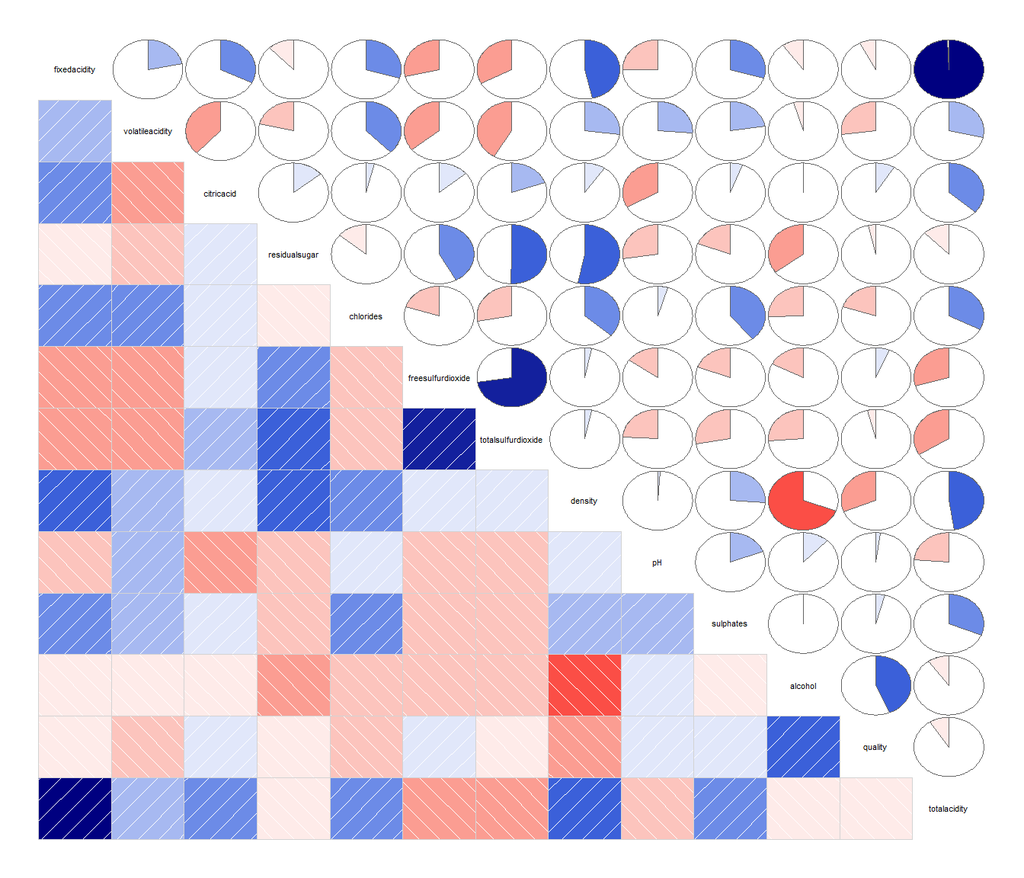

```r
matcor <- cor(wineCust_scale)
corrgram(matcor, type = "cor", lower.panel = panel.shade, upper.panel = panel.pie)
```

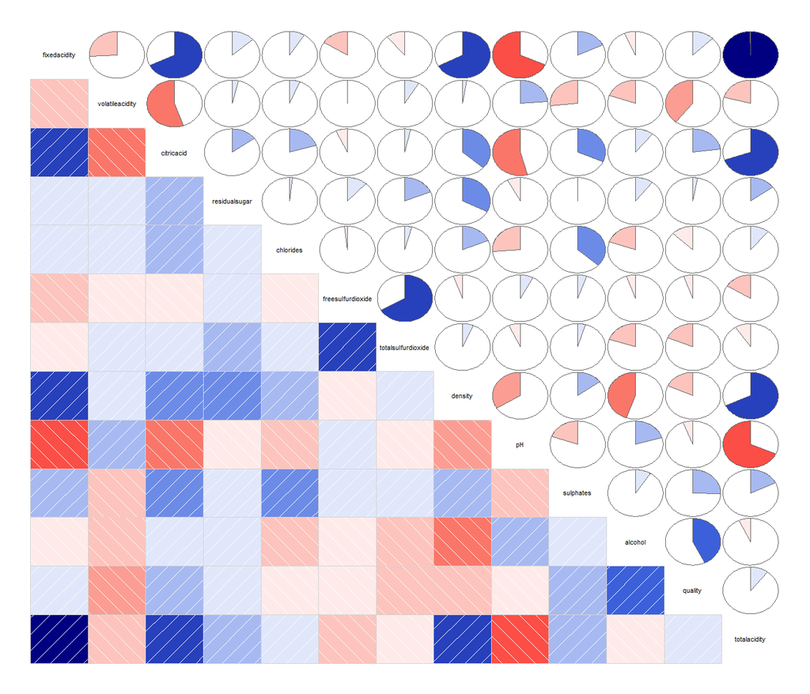

```r
matcor <- cor(wineCust_red_scale)
corrgram(matcor, type = "cor", lower.panel = panel.shade, upper.panel = panel.pie)
```

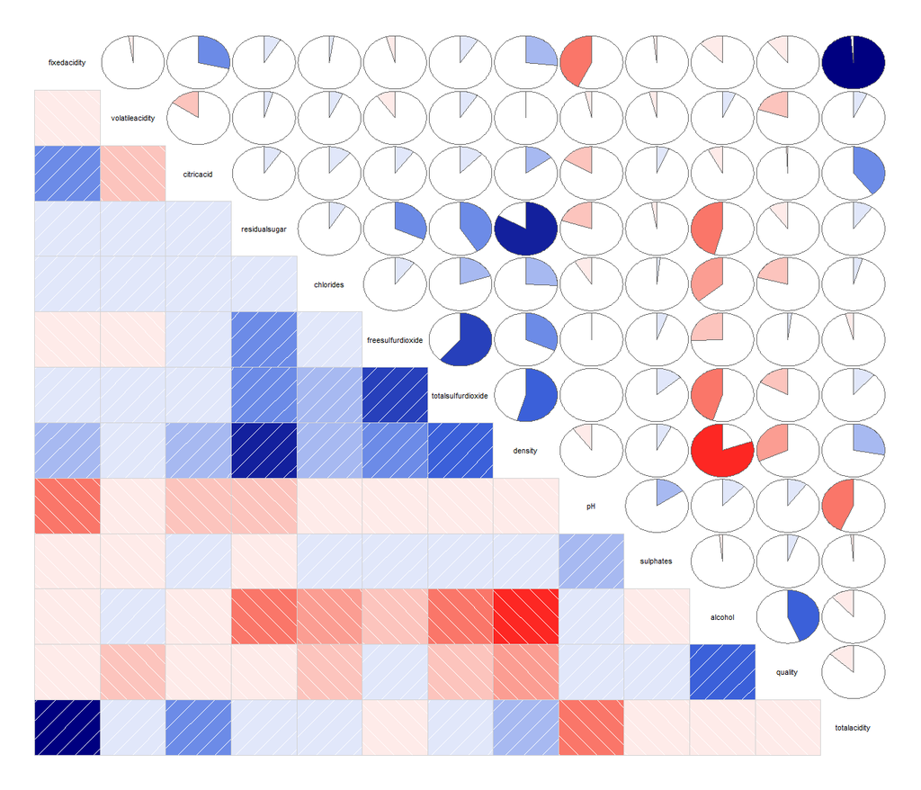

```r
matcor <- cor(wineCust__white_scale)
corrgram(matcor, type = "cor", lower.panel = panel.shade, upper.panel = panel.pie)
```

Podemos reparar que as correlacoes sao diferentes quando analisamos os tipos de vinhos separados

Agora que já entendemos a correlacao das variaveis, vamos verificar em quantos clusters podemos dividir a nossa clusterizacao

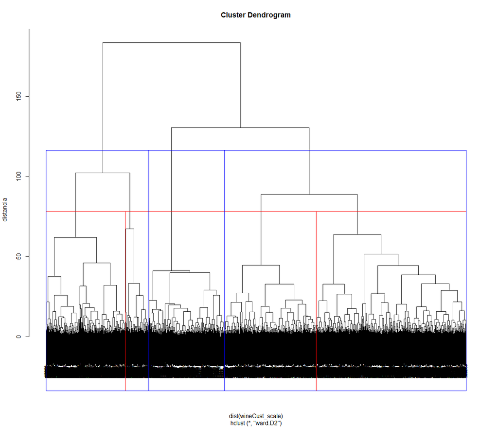

```r
# Vinhos juntos
hier_cluster<-hclust(dist(wineCust_scale),method='ward.D2')
d <- dist(wineCust_scale, method = "euclidean") # distance matrix
plot(hier_cluster, ylab='distancia', cex=0.6)
groups <- cutree(hier_cluster, k=5) # Divide em 5 clusters
rect.hclust(hier_cluster, k=5, border="red")
groups <- cutree(hier_cluster, k=3) # Divide em 3 clusters
rect.hclust(hier_cluster, k=3, border="blue")
```

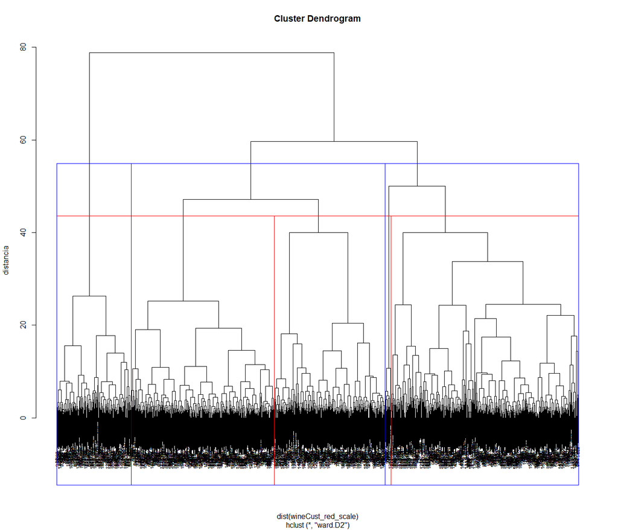

```r
# Vinhos vermelhos
hier_cluster<-hclust(dist(wineCust_red_scale),method='ward.D2')
d <- dist(wineCust_red_scale, method = "euclidean") # distance matrix
plot(hier_cluster, ylab='distancia', cex=0.6)
groups <- cutree(hier_cluster, k=5) # Divide em 5 clusters
rect.hclust(hier_cluster, k=5, border="red")
groups <- cutree(hier_cluster, k=3) # Divide em 3 clusters
rect.hclust(hier_cluster, k=3, border="blue")
```

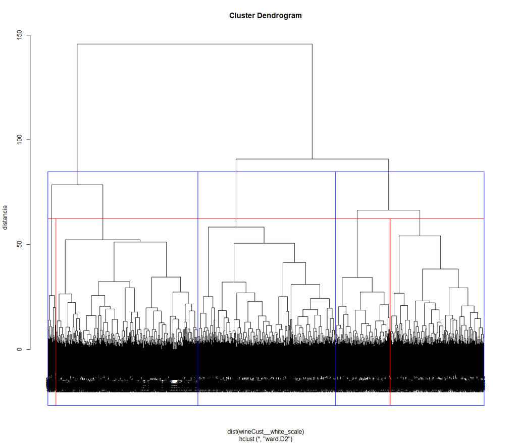

```r
#Vinhos brancos
hier_cluster<-hclust(dist(wineCust__white_scale),method='ward.D2')
d <- dist(wineCust__white_scale, method = "euclidean") # distance matrix
plot(hier_cluster, ylab='distancia', cex=0.6)
groups <- cutree(hier_cluster, k=5) # Divide em 5 clusters
rect.hclust(hier_cluster, k=5, border="red")
groups <- cutree(hier_cluster, k=3) # Divide em 3 clusters
rect.hclust(hier_cluster, k=3, border="blue")
```

Em todos os casos, nos pareceu mais interessante seguir com 5 clusters.

Mas para termos certeza, vamos seguir com mais um metodo, o elbow method

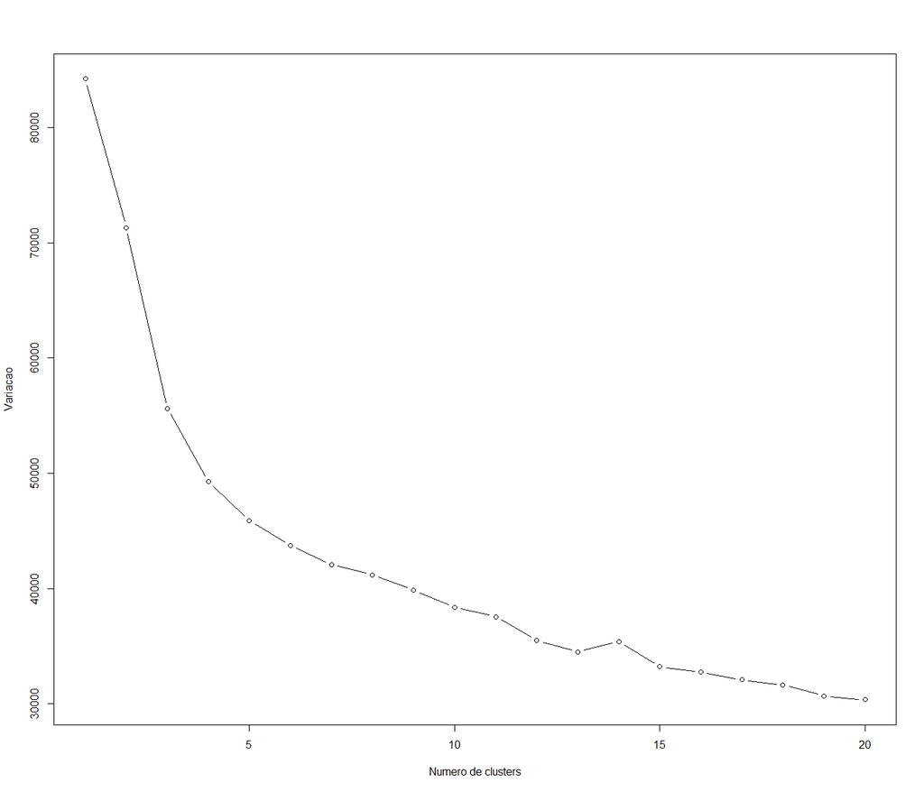

```r
# Todos os vinhos
wss <- (nrow(wineCust_scale)-1)*sum(apply(wineCust_scale,2,var))
for (i in 2:20) wss[i] <- sum(kmeans(wineCust_scale,
                                     centers=i)$withinss)
plot(1:20, wss, type="b", xlab="Numero de clusters",
     ylab="Variacao")
```

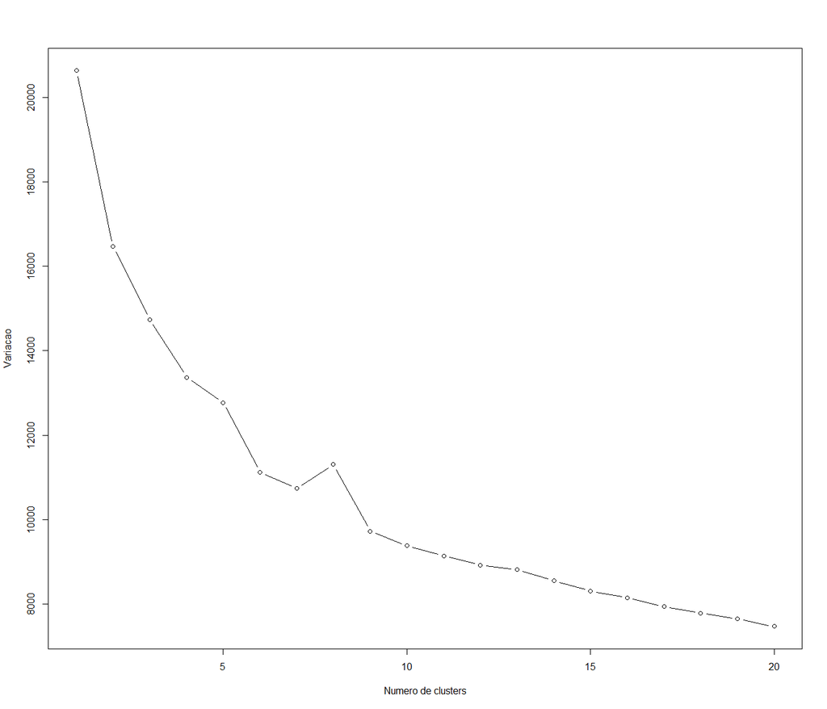

```r
# Apenas vinhos vermelhos
wss <- (nrow(wineCust_red_scale)-1)*sum(apply(wineCust_red_scale,2,var))
for (i in 2:20) wss[i] <- sum(kmeans(wineCust_red_scale,
                                     centers=i)$withinss)
plot(1:20, wss, type="b", xlab="Numero de clusters",
     ylab="Variacao")
```

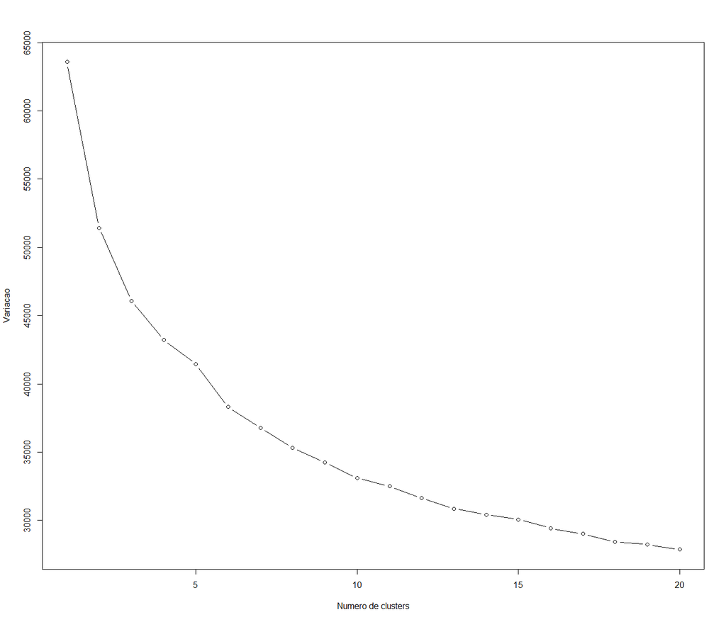

```r
# Apenas vinhos brancos
wss <- (nrow(wineCust__white_scale)-1)*sum(apply(wineCust__white_scale,2,var))
for (i in 2:20) wss[i] <- sum(kmeans(wineCust__white_scale,
                                     centers=i)$withinss)
plot(1:20, wss, type="b", xlab="Numero de clusters",
     ylab="Variacao")
```

De acordo com o Elbow method, achamos que poderia ser prudente seguirmos com numeros diferentes de clusters por dataset, mas para efeito de comparacao ficaremos com 6 clusters para todos os datasets:

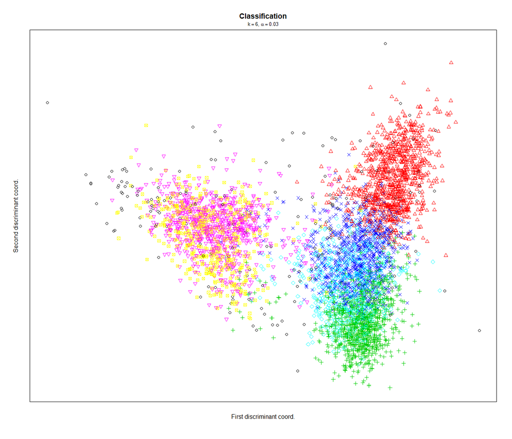

```r
# Todos os vinhos
attach(as.data.frame(wineCust_scale))
clus_teste <- tkmeans(wineCust_scale, k = 6, alpha = 0.03)
plot(clus_teste)
```

```r
# Vinhos vermelhos
attach(as.data.frame(wineCust_red_scale))
```

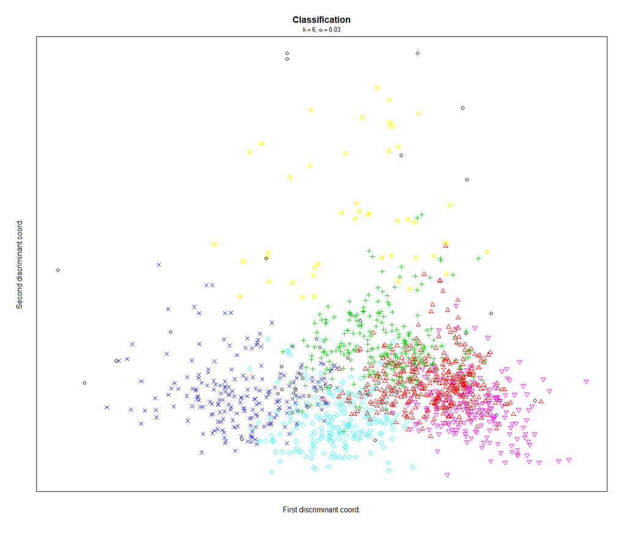

```r
clus_teste <- tkmeans(wineCust_red_scale, k = 6, alpha = 0.03)
plot(clus_teste)
```

```r
# Vinhos brancos
attach(as.data.frame(wineCust__white_scale))
```

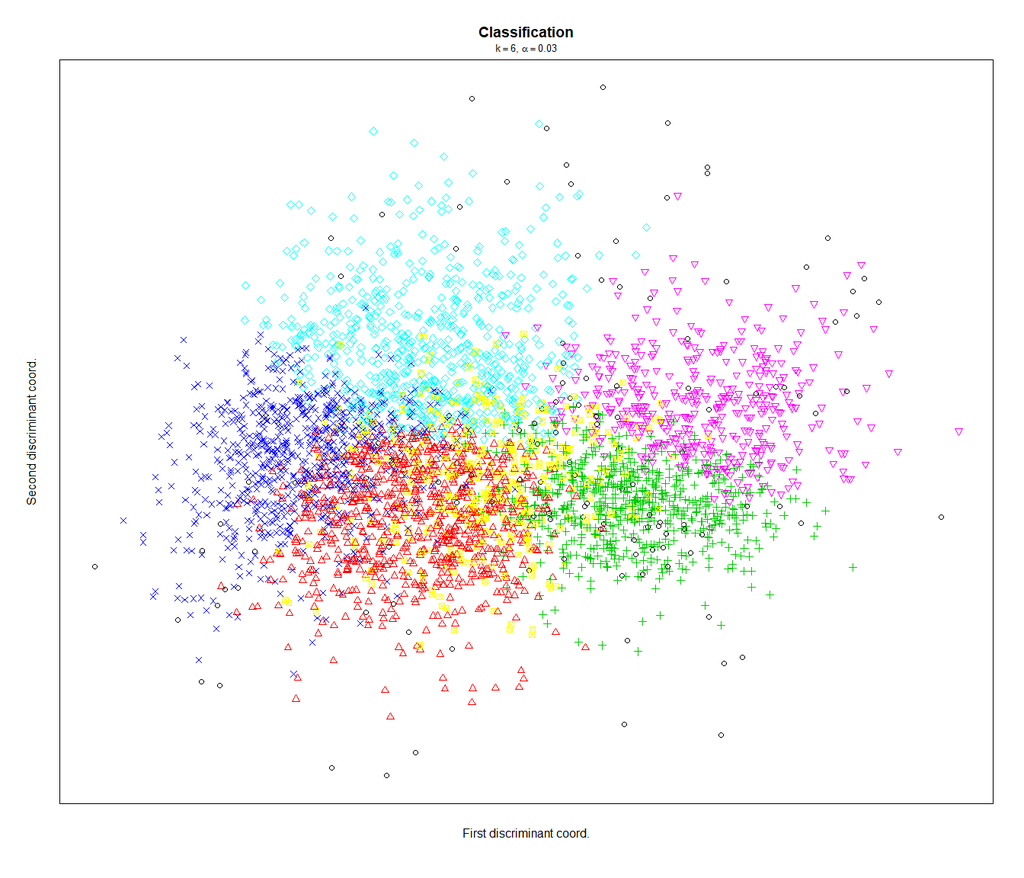

```r
clus_teste <- tkmeans(wineCust__white_scale, k = 6, alpha = 0.03)
plot(clus_teste)
```

## 4.2 Com PCA

As premissas sao exatamente as mesmas da analise sem PCA, por tanto: - Todos juntos - Brancos - Vermelhos

Separando os datasets em total, vermelho e white

```r
wineCust <- vinhos

winecust_red <- vinhosTintos
winecust_white <- vinhosBrancos
```

Rodando o PCA para encontrarmos quais componentes serao executados

```r
#wineCust_pr <- prcomp(scale(select (wineCust,-c(Vinho,id_vinho))))
prcomp(wineCust %>% dplyr::select(.,-c('id_vinho','Vinho','quality.cat'))) -> wineCust_pr
#winecust_red_pr <- prcomp(scale(select (winecust_red,-c(Vinho,id_vinho))))
prcomp(winecust_red %>% dplyr::select(.,-c('id_vinho','Vinho','quality.cat'))) -> winecust_red_pr
#winecust_white_pr <- prcomp(scale(select (winecust_white,-c(Vinho,id_vinho))))
prcomp(winecust_white %>% dplyr::select(.,-c('id_vinho','Vinho','quality.cat'))) -> winecust_white_pr

wineCust_scale_pr <- wineCust_pr$rotation[,1:9]
wineCust_red_scale_pr <- winecust_red_pr$rotation[,1:9]
wineCust__white_scale_pr <- winecust_white_pr$rotation[,1:9]
```

Agora com os datasets separados e normalizados podemos entender a correlacao de todos os datasets entre deles

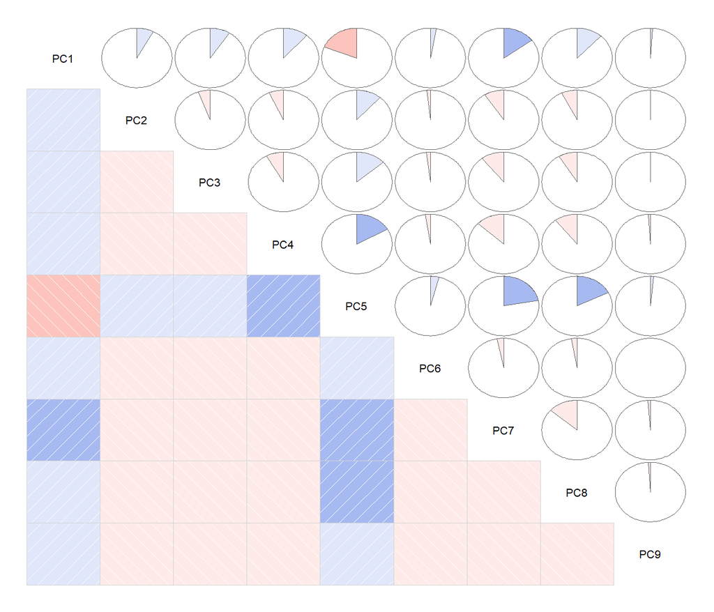

```r
matcor <- cor(wineCust_scale_pr)
corrgram(matcor, type = "cor", lower.panel = panel.shade, upper.panel = panel.pie)
```

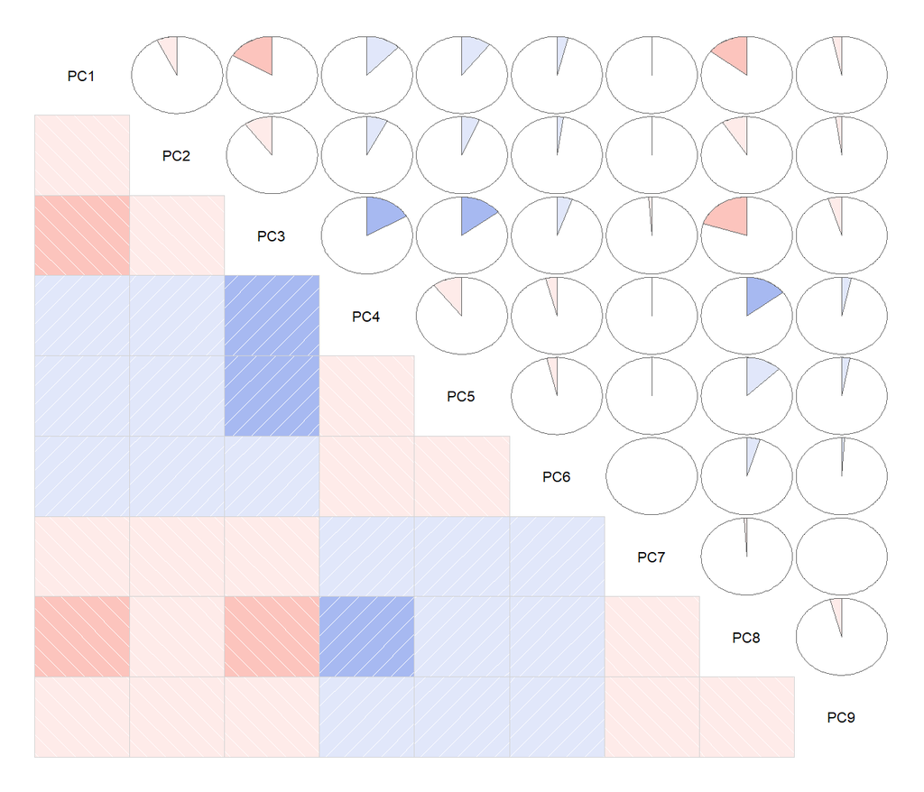

```r
matcor <- cor(wineCust_red_scale_pr)
corrgram(matcor, type = "cor", lower.panel = panel.shade, upper.panel = panel.pie)
```

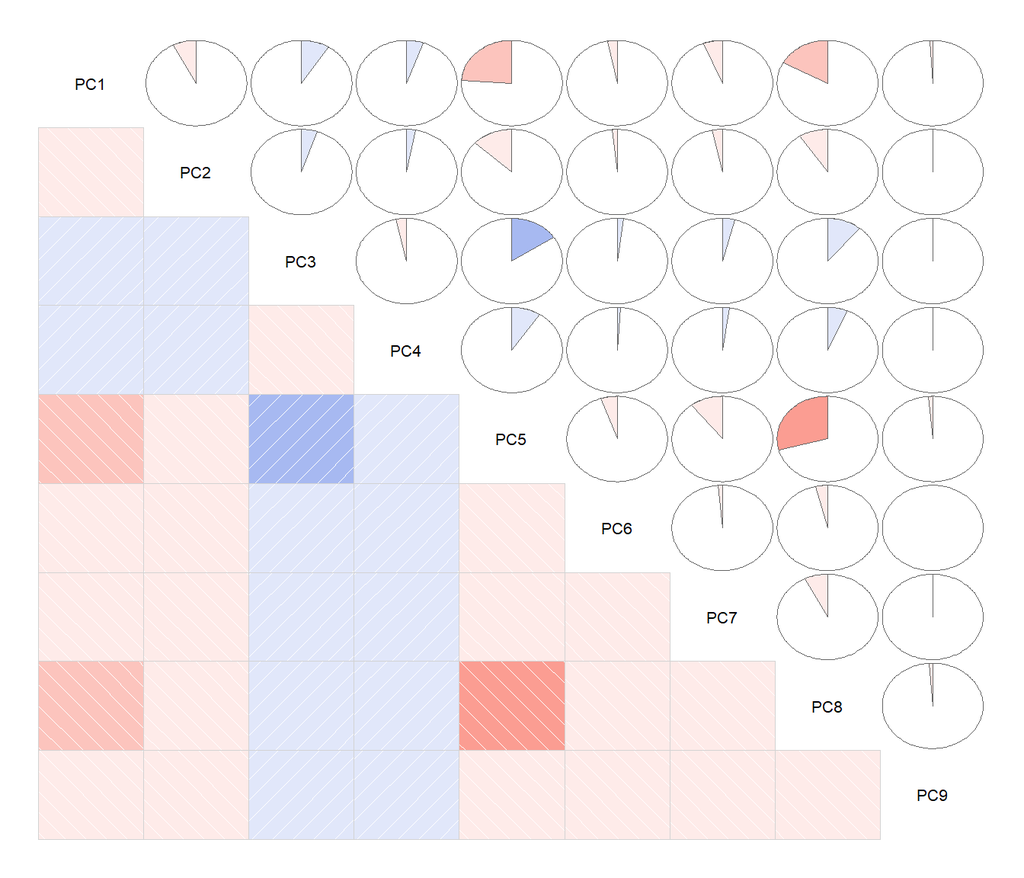

```r
matcor <- cor(wineCust__white_scale_pr)
corrgram(matcor, type = "cor", lower.panel = panel.shade, upper.panel = panel.pie)
```

Podemos reparar que as correlacoes sao diferentes quando analisamos os tipos de vinhos separados

Agora que já entendemos a correlacao das variaveis, vamos verificar em quantos clusters podemos dividir a nossa clusterizacao

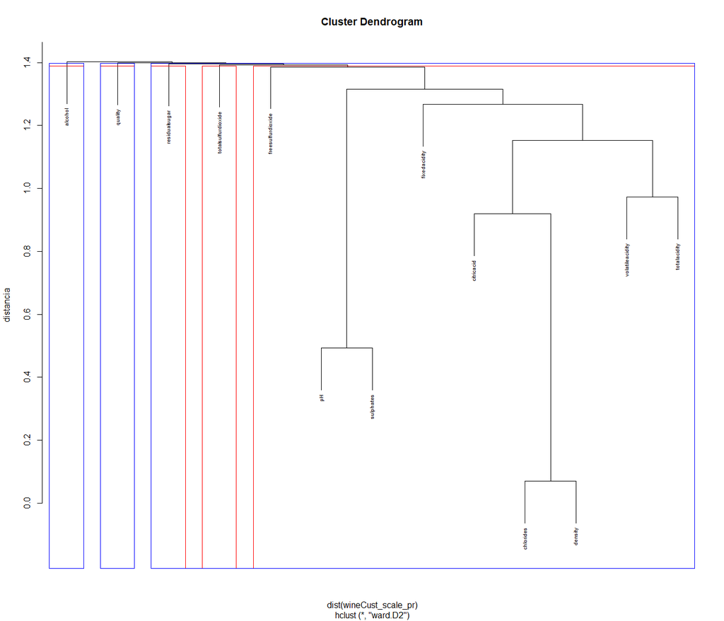

```r
# Vinhos juntos
hier_cluster<-hclust(dist(wineCust_scale_pr),method='ward.D2')
d <- dist(wineCust_scale_pr, method = "euclidean") # distance matrix
plot(hier_cluster, ylab='distancia', cex=0.6)
groups <- cutree(hier_cluster, k=5) # Divide em 5 clusters
rect.hclust(hier_cluster, k=5, border="red")
groups <- cutree(hier_cluster, k=3) # Divide em 3 clusters
rect.hclust(hier_cluster, k=3, border="blue")
```

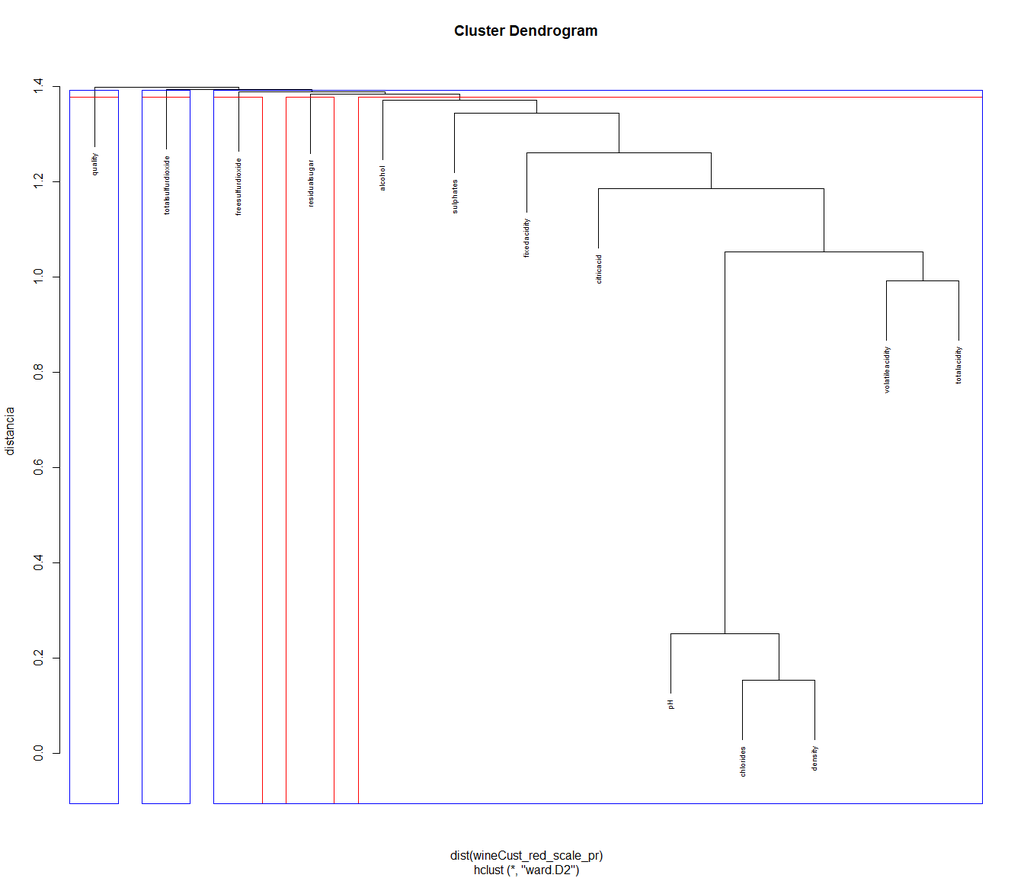

```r
# Vinhos vermelhos
hier_cluster<-hclust(dist(wineCust_red_scale_pr),method='ward.D2')
d <- dist(wineCust_red_scale_pr, method = "euclidean") # distance matrix
plot(hier_cluster, ylab='distancia', cex=0.6)
groups <- cutree(hier_cluster, k=5) # Divide em 5 clusters
rect.hclust(hier_cluster, k=5, border="red")
groups <- cutree(hier_cluster, k=3) # Divide em 3 clusters
rect.hclust(hier_cluster, k=3, border="blue")
```

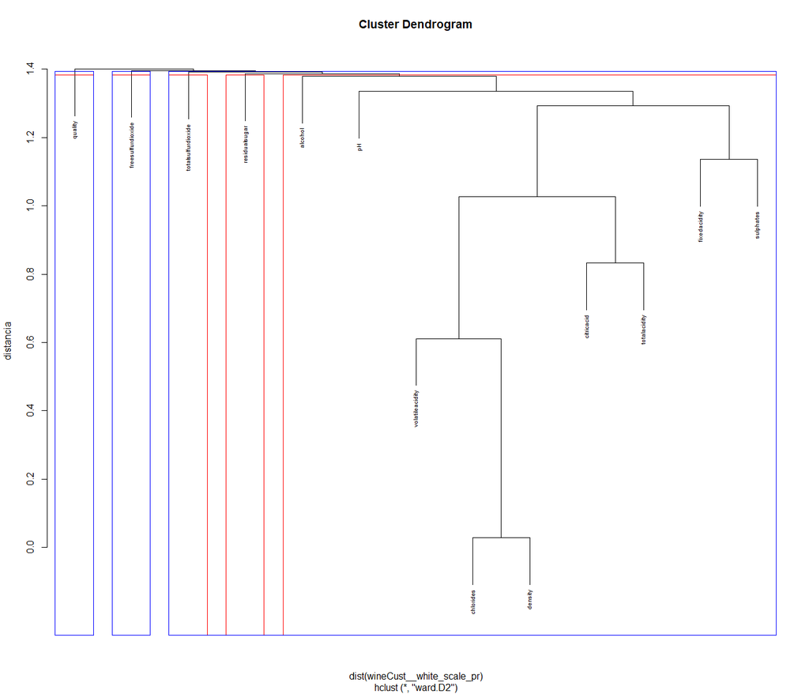

```r
#Vinhos brancos
hier_cluster<-hclust(dist(wineCust__white_scale_pr),method='ward.D2')
d <- dist(wineCust__white_scale_pr, method = "euclidean") # distance matrix
plot(hier_cluster, ylab='distancia', cex=0.6)
groups <- cutree(hier_cluster, k=5) # Divide em 5 clusters
rect.hclust(hier_cluster, k=5, border="red")
groups <- cutree(hier_cluster, k=3) # Divide em 3 clusters
rect.hclust(hier_cluster, k=3, border="blue")
```

Em todos os casos, nos pareceu mais interessante seguir com 5 clusters.

Mas para termos certeza, vamos seguir com mais um metodo, o elbow method

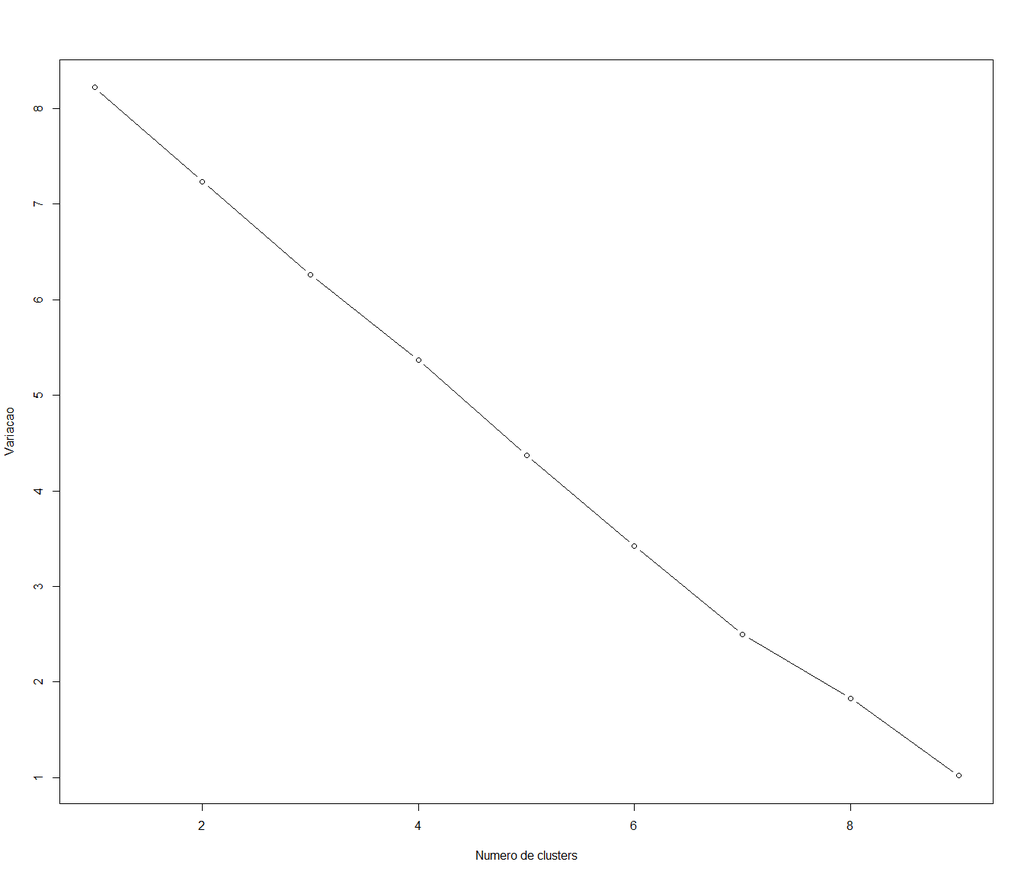

```r
# Todos os vinhos
wss <- (nrow(wineCust_scale_pr)-1)*sum(apply(wineCust_scale_pr,2,var))
for (i in 1:9) wss[i] <- sum(kmeans(wineCust_scale_pr,
                                     centers=i)$withinss)
plot(1:9, wss, type="b", xlab="Numero de clusters",
     ylab="Variacao")
```

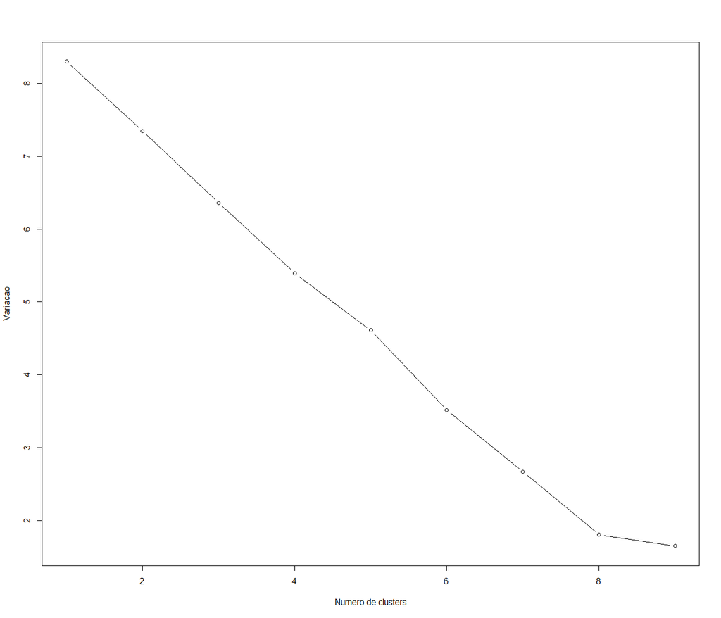

```r
# Apenas vinhos vermelhos
wss <- (nrow(wineCust_red_scale_pr)-1)*sum(apply(wineCust_red_scale_pr,2,var))
for (i in 1:9) wss[i] <- sum(kmeans(wineCust_red_scale_pr,
                                     centers=i)$withinss)
plot(1:9, wss, type="b", xlab="Numero de clusters",
     ylab="Variacao")
```

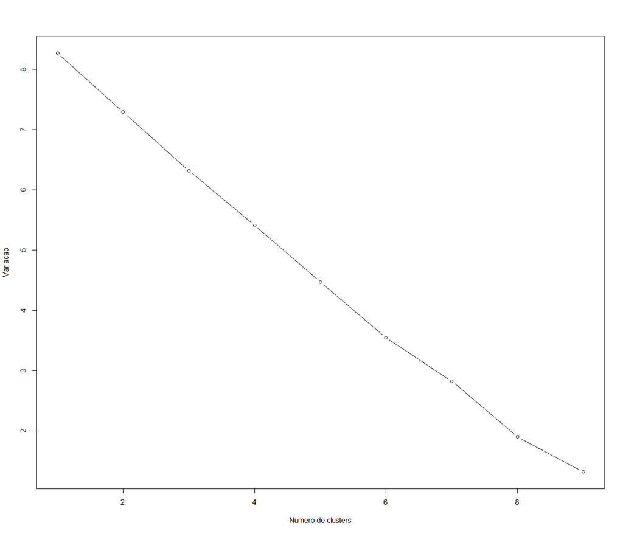

```r
# Apenas vinhos brancos
wss <- (nrow(wineCust__white_scale_pr)-1)*sum(apply(wineCust__white_scale_pr,2,var))
for (i in 1:9) wss[i] <- sum(kmeans(wineCust__white_scale_pr,
                                     centers=i)$withinss)
plot(1:9, wss, type="b", xlab="Numero de clusters",
     ylab="Variacao")
```

A variação se mostrou muito diferente utilizando PCA, mas para efeitos de comparacao continuaremos com 6 clusters:

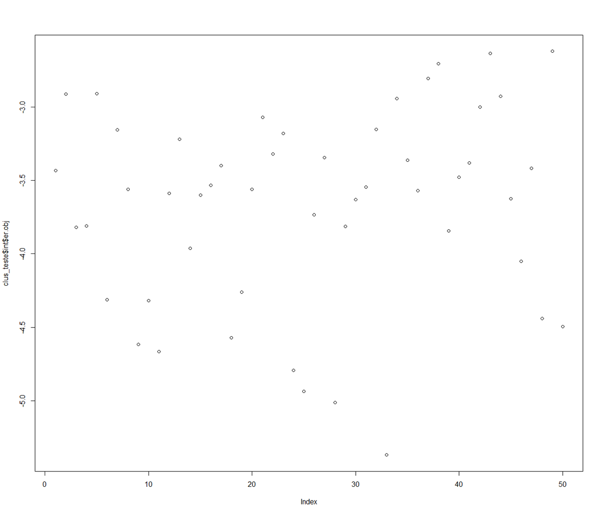

```r
# Todos os vinhos
attach(as.data.frame(wineCust_scale_pr))
clus_teste <- tkmeans(wineCust_scale_pr, k = 6, alpha = 0.03)
plot(clus_teste$int$er.obj)
```